# The_Analytics_Edge_edX_MIT15.071x_June2015

Course Notes by Nishant Upadhyay Unit 1 & 2

June 2015

*Source file* ⇒ The_Analytics_Edge_edX_MIT062015.Rmd

## Unit 1: An Introduction to Analytics

### Preliminaries

- These are my notes for the lectures of the [The_Analytics_Edge_edX_MIT15.071x_June2015“](https://courses.edx.org/courses/course-v1:MITx+15.071x_2a+2T2015) by Professor Dimitris Bertsimas. The goal of these notes is to provide the reproducible R code for all the lectures.
- I use (and strongly recommend) [RStudio](http://www.rstudio.com/) to do all my work in R. I wrote them with a *work-in-progress* R user in mind (that means, non-absolute newbie but non-expert either). There are now hundreds of ways of learning R. I recommend the course [R Programming](https://www.coursera.org/course/rprog) by R. Peng, J. Leek and B. Caffo (the course is part of the *Data Science Specialization*, which I also recommend if you are willing to learn a lot about data science using R). Also, the [Open Intro Statistics](https://www.openintro.org/index.php) R labs can be useful. I have also often found the following websites very useful:
  - [R resources at the Institute for Digital Research and Education, UCLA](http://www.ats.ucla.edu/stat/r/)
  - [Quick-R by Robert Kabacoff](http://www.statmethods.net/)
  - [R-Tutorial by Chi Yau](http://www.r-tutor.com/)
  - [R-Tutorials by William King](http://ww2.coastal.edu/kingw/statistics/R-tutorials/)
  - [R search engine created and maintained by Sasha Goodman](https://rstudio-pubs-static.s3.amazonaws.com/www.rseek.org)
  - [UCLA Resources to help you learn and use R](http://www.ats.ucla.edu/stat/r/)
  - [R Site Search](http://finzi.psych.upenn.edu/search.html)
  - [swirl_interactive R training](http://swirlstats.com/students.html)
- The notes are written in [Rmarkdown](http://rmarkdown.rstudio.com/), which is based on [knitr](http://yihui.name/knitr/). The R code appears in darker grey boxes, while the output appears below in white boxes (the output appears here prefixed with ##, but that’s not really part of R output; see the Rmarkdown and knitr references for details). The important thing is that you can copy the code from the grey boxes, paste it into R and execute it directly.

**IMPORTANT NOTE**

If you downloaded and installed R in a location other than the United States, you might encounter some formating issues later in this class due to language differences. To fix this, you will need to type in your R console:

Sys.setlocale(“LC_ALL”, “C”)

This will only change the locale for your current R session, so please make a note to run this command when you are working on any lectures or exercises that might depend on the English language (for example, the names for the days of the week).

### Working with data_An introduction to R

Please download and install R for free from the following webpage:http://www.cran.r-project.org

### QUICK QUESTIONS FOR INSTALLING R

When you start R, you should see a window titled “R Console”. In this window, there is some text, and then at the bottom there should be a > symbol (greater than symbol), followed by a blinking cursor. At the cursor, type:

sd(c(5,8,12))

and then hit enter. You should see [1] followed by a number. What is this number?

```r
sd(c(5,8,12))
```

```
## [1] 3.511885
```

Ans:3.511885

Now type:

which.min(c(4,1,6))

at the cursor, and hit enter. You should again see [1], followed by a number. What is this number?

```r
which.min(c(4,1,6))
```

```
## [1] 2
```

Ans:2

`which.min` gives the *position* of the *min value* of the data set/vector

Q:At which university was the first version of R developed?

Ans:University of Auckland

EXPLANATION:The first version of R was developed by Robert Gentleman and Ross Ihaka at the University of Auckland in the mid-1990s.

Q:Which of the following are recommended variable names in R? (Select all that apply.)

Ans:SquareRoot2

Square2.Root

EXPLANATION:SquareRoot2 and Square2.Root are recommended variable names. The second option is not recommended because it has a space, and the fourth option is not recommended because it starts with a number.

Q:If you want to add new observations to a data frame, what should you use?

Ans:The rbind function.

EXPLANATION:To add new observations to a data frame with the same variable values, you should use rbind.

Q:If you want to combine two vectors into a data frame, what should you use?

Ans:The data.frame function.

EXPLANATION:To combine two vectors into a data frame, you should use data.frame.

Q:If you want to add a variable to your data frame, what should you use?

Ans:The dollar sign notation.

EXPLANATION:To add a variable to your data frame, you should the dollar sign notation.

Q:If you want to know the mean value of a numerical variable, which function could you use?

Ans:summary

EXPLANATION:If you using the summary function (in the video, we typed summary(WHO) in our R console) you can see a statistical summary of each variable. For numerical variables, the mean value is listed.

Q:If you want to know the standard deviation of a numerical variable, which function could you use?

EXPLANATION:Neither the str function nor the summary function provides the standard deviation value of a variable. We’ll see how to compute this value in the next video.

```r
#importing the WHO dataset
WHO<-read.csv("WHO.csv")
str(WHO)
```

```
## 'data.frame':    194 obs. of  13 variables:
##  $ Country                      : Factor w/ 194 levels "Afghanistan",..: 1 2 3 4 5 6 7 8 9 10 ...
##  $ Region                       : Factor w/ 6 levels "Africa","Americas",..: 3 4 1 4 1 2 2 4 6 4 ...
##  $ Population                   : int  29825 3162 38482 78 20821 89 41087 2969 23050 8464 ...
##  $ Under15                      : num  47.4 21.3 27.4 15.2 47.6 ...
##  $ Over60                       : num  3.82 14.93 7.17 22.86 3.84 ...
##  $ FertilityRate                : num  5.4 1.75 2.83 NA 6.1 2.12 2.2 1.74 1.89 1.44 ...
##  $ LifeExpectancy               : int  60 74 73 82 51 75 76 71 82 81 ...
##  $ ChildMortality               : num  98.5 16.7 20 3.2 163.5 ...
##  $ CellularSubscribers          : num  54.3 96.4 99 75.5 48.4 ...
##  $ LiteracyRate                 : num  NA NA NA NA 70.1 99 97.8 99.6 NA NA ...
##  $ GNI                          : num  1140 8820 8310 NA 5230 ...
##  $ PrimarySchoolEnrollmentMale  : num  NA NA 98.2 78.4 93.1 91.1 NA NA 96.9 NA ...
##  $ PrimarySchoolEnrollmentFemale: num  NA NA 96.4 79.4 78.2 84.5 NA NA 97.5 NA ...
```

```r
summary(WHO)
```

```
##                 Country                      Region     Population
##  Afghanistan        :  1   Africa               :46   Min.   :      1
##  Albania            :  1   Americas             :35   1st Qu.:   1696
##  Algeria            :  1   Eastern Mediterranean:22   Median :   7790
##  Andorra            :  1   Europe               :53   Mean   :  36360
##  Angola             :  1   South-East Asia      :11   3rd Qu.:  24535
##  Antigua and Barbuda:  1   Western Pacific      :27   Max.   :1390000
##  (Other)            :188
##     Under15          Over60      FertilityRate   LifeExpectancy
##  Min.   :13.12   Min.   : 0.81   Min.   :1.260   Min.   :47.00
##  1st Qu.:18.72   1st Qu.: 5.20   1st Qu.:1.835   1st Qu.:64.00
##  Median :28.65   Median : 8.53   Median :2.400   Median :72.50
##  Mean   :28.73   Mean   :11.16   Mean   :2.941   Mean   :70.01
##  3rd Qu.:37.75   3rd Qu.:16.69   3rd Qu.:3.905   3rd Qu.:76.00
##  Max.   :49.99   Max.   :31.92   Max.   :7.580   Max.   :83.00
##                                  NA's   :11
##  ChildMortality    CellularSubscribers  LiteracyRate        GNI
##  Min.   :  2.200   Min.   :  2.57      Min.   :31.10   Min.   :  340
##  1st Qu.:  8.425   1st Qu.: 63.57      1st Qu.:71.60   1st Qu.: 2335
##  Median : 18.600   Median : 97.75      Median :91.80   Median : 7870
##  Mean   : 36.149   Mean   : 93.64      Mean   :83.71   Mean   :13321
##  3rd Qu.: 55.975   3rd Qu.:120.81      3rd Qu.:97.85   3rd Qu.:17558
##  Max.   :181.600   Max.   :196.41      Max.   :99.80   Max.   :86440
##                    NA's   :10          NA's   :91      NA's   :32
##  PrimarySchoolEnrollmentMale PrimarySchoolEnrollmentFemale
##  Min.   : 37.20              Min.   : 32.50
##  1st Qu.: 87.70              1st Qu.: 87.30
##  Median : 94.70              Median : 95.10
##  Mean   : 90.85              Mean   : 89.63
##  3rd Qu.: 98.10              3rd Qu.: 97.90
##  Max.   :100.00              Max.   :100.00
##  NA's   :93                  NA's   :93
```

```r
#Q:What is the mean value of the "Over60" variable?
mean(WHO$Over60)
```

```
## [1] 11.16366
```

```r
#Ans:11.16366
#EXPLANATION:You can compute this value by either typing mean(WHO$Over60) in your R console, or by typing summary(WHO$Over60) in your R console. The output is 11.16.

#Q:Which country has the smallest percentage of the population over 60?
which.min(WHO$Over60)
```

```
## [1] 183
```

```r
WHO$Country[183]
```

```
## [1] United Arab Emirates
## 194 Levels: Afghanistan Albania Algeria Andorra ... Zimbabwe
```

```r
#Ans:United Arab Emirates
#EXPLANATION:To get this value, you should type which.min(WHO$Over60) in your R console. The output is 183. Then, to see the name of the 183rd country in your data frame, type WHO$Country[183] in your R console. The output is United Arab Emirates.

#Q:Which country has the largest literacy rate?
which.max(WHO$LiteracyRate)
```

```
## [1] 44
```

```r
WHO$Country[44]
```

```
## [1] Cuba
## 194 Levels: Afghanistan Albania Algeria Andorra ... Zimbabwe
```

```r
#Ans:Cuba
#EXPLANATION:To get this value, you should type which.max(WHO$LiteracyRate) in your R console. The output is 44. Then, to see the name of the 44th country in your data frame, type WHO$Country[44] in your R console. The output is Cuba.

#Q:Use the tapply function to find the average child mortality rate of countries in each region.
#Which region has the lowest average child mortality rate across all countries in that region?
tapply(WHO$ChildMortality, WHO$Region, mean)
```

```
##                Africa              Americas Eastern Mediterranean
##              84.03696              19.32286              40.25000
##                Europe       South-East Asia       Western Pacific
##              10.05094              35.04545              24.71111
```

```r
#Ans:Europe
```

### Working with data_An introduction to R (R lecture videos reproduced)

```r
# VIDEO 2

# Basic Calculations
8*6
```

```
## [1] 48
```

```r
2^16
```

```
## [1] 65536
```

```r
2^
8*6
```

```
## [1] 1536
```

```r
8*10
```

```
## [1] 80
```

```r
# Functions
sqrt(2)
```

```
## [1] 1.414214
```

```r
abs(-65)
```

```
## [1] 65
```

```r
#?sqrt

# Variables
SquareRoot2 = sqrt(2)
SquareRoot2
```

```
## [1] 1.414214
```

```r
HoursYear <- 365*24
HoursYear
```

```
## [1] 8760
```

```r
ls()
```

```
## [1] "HoursYear"   "SquareRoot2" "WHO"
```

```r
# VIDEO 3

# Vectors
c(2,3,5,8,13)
```

```
## [1]  2  3  5  8 13
```

```r
Country = c("Brazil", "China", "India","Switzerland","USA")
LifeExpectancy = c(74,76,65,83,79)
Country
```

```
## [1] "Brazil"      "China"       "India"       "Switzerland" "USA"
```

```r
LifeExpectancy
```

```
## [1] 74 76 65 83 79
```

```r
Country[1]
```

```
## [1] "Brazil"
```

```r
LifeExpectancy[3]
```

```
## [1] 65
```

```r
Sequence = seq(0,100,2)
Sequence
```

```
##  [1]   0   2   4   6   8  10  12  14  16  18  20  22  24  26  28  30  32
## [18]  34  36  38  40  42  44  46  48  50  52  54  56  58  60  62  64  66
## [35]  68  70  72  74  76  78  80  82  84  86  88  90  92  94  96  98 100
```

```r
# Data Frames
CountryData = data.frame(Country, LifeExpectancy)
CountryData
```

```
##       Country LifeExpectancy
## 1      Brazil             74
## 2       China             76
## 3       India             65
## 4 Switzerland             83
## 5         USA             79
```

```r
CountryData$Population = c(199000,1390000,1240000,7997,318000)
CountryData
```

```
##       Country LifeExpectancy Population
## 1      Brazil             74     199000
## 2       China             76    1390000
## 3       India             65    1240000
## 4 Switzerland             83       7997
## 5         USA             79     318000
```

```r
Country = c("Australia","Greece")
LifeExpectancy = c(82,81)
Population = c(23050,11125)
NewCountryData = data.frame(Country, LifeExpectancy, Population)
NewCountryData
```

```
##     Country LifeExpectancy Population
## 1 Australia             82      23050
## 2    Greece             81      11125
```

```r
AllCountryData = rbind(CountryData, NewCountryData)
AllCountryData
```

```
##       Country LifeExpectancy Population
## 1      Brazil             74     199000
## 2       China             76    1390000
## 3       India             65    1240000
## 4 Switzerland             83       7997
## 5         USA             79     318000
## 6   Australia             82      23050
## 7      Greece             81      11125
```

```r
# VIDEO 4

# Loading csv files
WHO<-read.csv("WHO.csv")
str(WHO)
```

```
## 'data.frame':    194 obs. of  13 variables:
##  $ Country                      : Factor w/ 194 levels "Afghanistan",..: 1 2 3 4 5 6 7 8 9 10 ...
##  $ Region                       : Factor w/ 6 levels "Africa","Americas",..: 3 4 1 4 1 2 2 4 6 4 ...
##  $ Population                   : int  29825 3162 38482 78 20821 89 41087 2969 23050 8464 ...
##  $ Under15                      : num  47.4 21.3 27.4 15.2 47.6 ...
##  $ Over60                       : num  3.82 14.93 7.17 22.86 3.84 ...
##  $ FertilityRate                : num  5.4 1.75 2.83 NA 6.1 2.12 2.2 1.74 1.89 1.44 ...
##  $ LifeExpectancy               : int  60 74 73 82 51 75 76 71 82 81 ...
##  $ ChildMortality               : num  98.5 16.7 20 3.2 163.5 ...
##  $ CellularSubscribers          : num  54.3 96.4 99 75.5 48.4 ...
##  $ LiteracyRate                 : num  NA NA NA NA 70.1 99 97.8 99.6 NA NA ...
##  $ GNI                          : num  1140 8820 8310 NA 5230 ...
##  $ PrimarySchoolEnrollmentMale  : num  NA NA 98.2 78.4 93.1 91.1 NA NA 96.9 NA ...
##  $ PrimarySchoolEnrollmentFemale: num  NA NA 96.4 79.4 78.2 84.5 NA NA 97.5 NA ...
```

```r
summary(WHO)
```

```
##                 Country                      Region     Population
##  Afghanistan        :  1   Africa               :46   Min.   :      1
##  Albania            :  1   Americas             :35   1st Qu.:   1696
##  Algeria            :  1   Eastern Mediterranean:22   Median :   7790
##  Andorra            :  1   Europe               :53   Mean   :  36360
##  Angola             :  1   South-East Asia      :11   3rd Qu.:  24535
##  Antigua and Barbuda:  1   Western Pacific      :27   Max.   :1390000
##  (Other)            :188
##     Under15          Over60      FertilityRate   LifeExpectancy
##  Min.   :13.12   Min.   : 0.81   Min.   :1.260   Min.   :47.00
##  1st Qu.:18.72   1st Qu.: 5.20   1st Qu.:1.835   1st Qu.:64.00
##  Median :28.65   Median : 8.53   Median :2.400   Median :72.50
##  Mean   :28.73   Mean   :11.16   Mean   :2.941   Mean   :70.01
##  3rd Qu.:37.75   3rd Qu.:16.69   3rd Qu.:3.905   3rd Qu.:76.00
##  Max.   :49.99   Max.   :31.92   Max.   :7.580   Max.   :83.00
##                                  NA's   :11
##  ChildMortality    CellularSubscribers  LiteracyRate        GNI
##  Min.   :  2.200   Min.   :  2.57      Min.   :31.10   Min.   :  340
##  1st Qu.:  8.425   1st Qu.: 63.57      1st Qu.:71.60   1st Qu.: 2335
##  Median : 18.600   Median : 97.75      Median :91.80   Median : 7870
##  Mean   : 36.149   Mean   : 93.64      Mean   :83.71   Mean   :13321
##  3rd Qu.: 55.975   3rd Qu.:120.81      3rd Qu.:97.85   3rd Qu.:17558
##  Max.   :181.600   Max.   :196.41      Max.   :99.80   Max.   :86440
##                    NA's   :10          NA's   :91      NA's   :32
##  PrimarySchoolEnrollmentMale PrimarySchoolEnrollmentFemale
##  Min.   : 37.20              Min.   : 32.50
##  1st Qu.: 87.70              1st Qu.: 87.30
##  Median : 94.70              Median : 95.10
##  Mean   : 90.85              Mean   : 89.63
##  3rd Qu.: 98.10              3rd Qu.: 97.90
##  Max.   :100.00              Max.   :100.00
##  NA's   :93                  NA's   :93
```

```r
# Subsetting
WHO_Europe = subset(WHO, Region == "Europe")
str(WHO_Europe)
```

```
## 'data.frame':    53 obs. of  13 variables:
##  $ Country                      : Factor w/ 194 levels "Afghanistan",..: 2 4 8 10 11 16 17 22 26 42 ...
##  $ Region                       : Factor w/ 6 levels "Africa","Americas",..: 4 4 4 4 4 4 4 4 4 4 ...
##  $ Population                   : int  3162 78 2969 8464 9309 9405 11060 3834 7278 4307 ...
##  $ Under15                      : num  21.3 15.2 20.3 14.5 22.2 ...
##  $ Over60                       : num  14.93 22.86 14.06 23.52 8.24 ...
##  $ FertilityRate                : num  1.75 NA 1.74 1.44 1.96 1.47 1.85 1.26 1.51 1.48 ...
##  $ LifeExpectancy               : int  74 82 71 81 71 71 80 76 74 77 ...
##  $ ChildMortality               : num  16.7 3.2 16.4 4 35.2 5.2 4.2 6.7 12.1 4.7 ...
##  $ CellularSubscribers          : num  96.4 75.5 103.6 154.8 108.8 ...
##  $ LiteracyRate                 : num  NA NA 99.6 NA NA NA NA 97.9 NA 98.8 ...
##  $ GNI                          : num  8820 NA 6100 42050 8960 ...
##  $ PrimarySchoolEnrollmentMale  : num  NA 78.4 NA NA 85.3 NA 98.9 86.5 99.3 94.8 ...
##  $ PrimarySchoolEnrollmentFemale: num  NA 79.4 NA NA 84.1 NA 99.2 88.4 99.7 97 ...
```

```r
# Writing csv files
write.csv(WHO_Europe, "WHO_Europe.csv")

# Removing variables
rm(WHO_Europe)


# VIDEO 5

# Basic data analysis

mean(WHO$Under15)
```

```
## [1] 28.73242
```

```r
sd(WHO$Under15)
```

```
## [1] 10.53457
```

```r
summary(WHO$Under15)
```

```
##    Min. 1st Qu.  Median    Mean 3rd Qu.    Max.
##   13.12   18.72   28.65   28.73   37.75   49.99
```

```r
which.min(WHO$Under15)
```

```
## [1] 86
```

```r
WHO$Country[86]
```

```
## [1] Japan
## 194 Levels: Afghanistan Albania Algeria Andorra ... Zimbabwe
```

```r
which.max(WHO$Under15)
```

```
## [1] 124
```

```r
WHO$Country[124]
```

```
## [1] Niger
## 194 Levels: Afghanistan Albania Algeria Andorra ... Zimbabwe
```

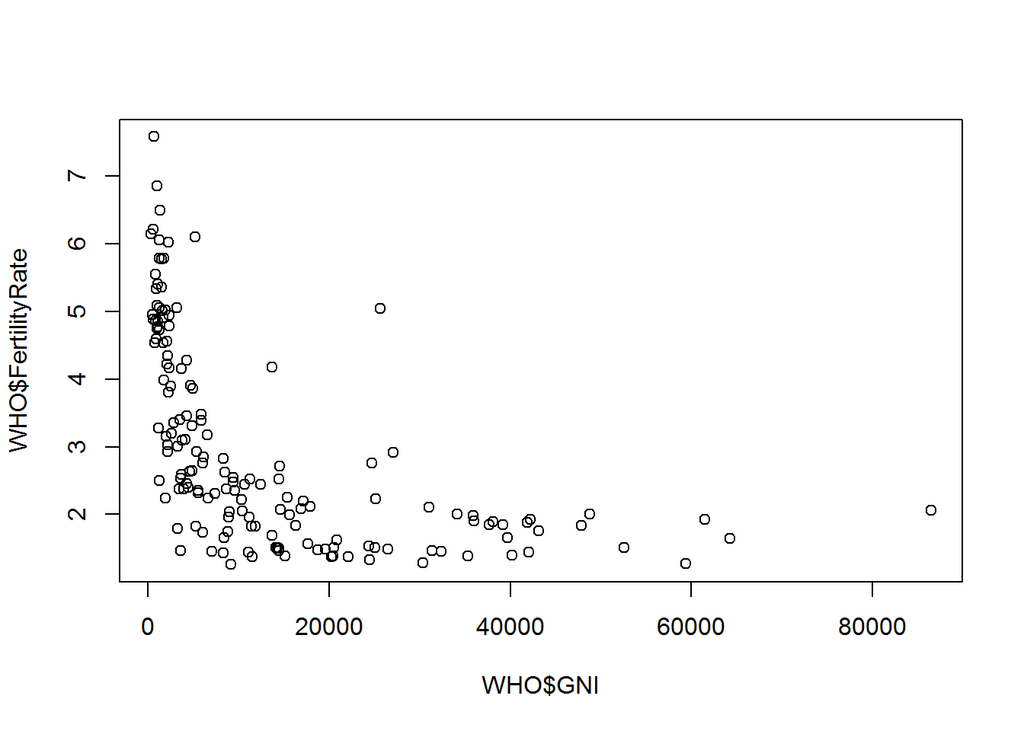

```r
# Scatterplot
plot(WHO$GNI, WHO$FertilityRate)
```

```r
# Subsetting
Outliers = subset(WHO, GNI > 10000 & FertilityRate > 2.5)
nrow(Outliers)
```

```
## [1] 7
```

```r
Outliers[c("Country","GNI","FertilityRate")]
```

```
##               Country   GNI FertilityRate
## 23           Botswana 14550          2.71
## 56  Equatorial Guinea 25620          5.04
## 63              Gabon 13740          4.18
## 83             Israel 27110          2.92
## 88         Kazakhstan 11250          2.52
## 131            Panama 14510          2.52
## 150      Saudi Arabia 24700          2.76
```

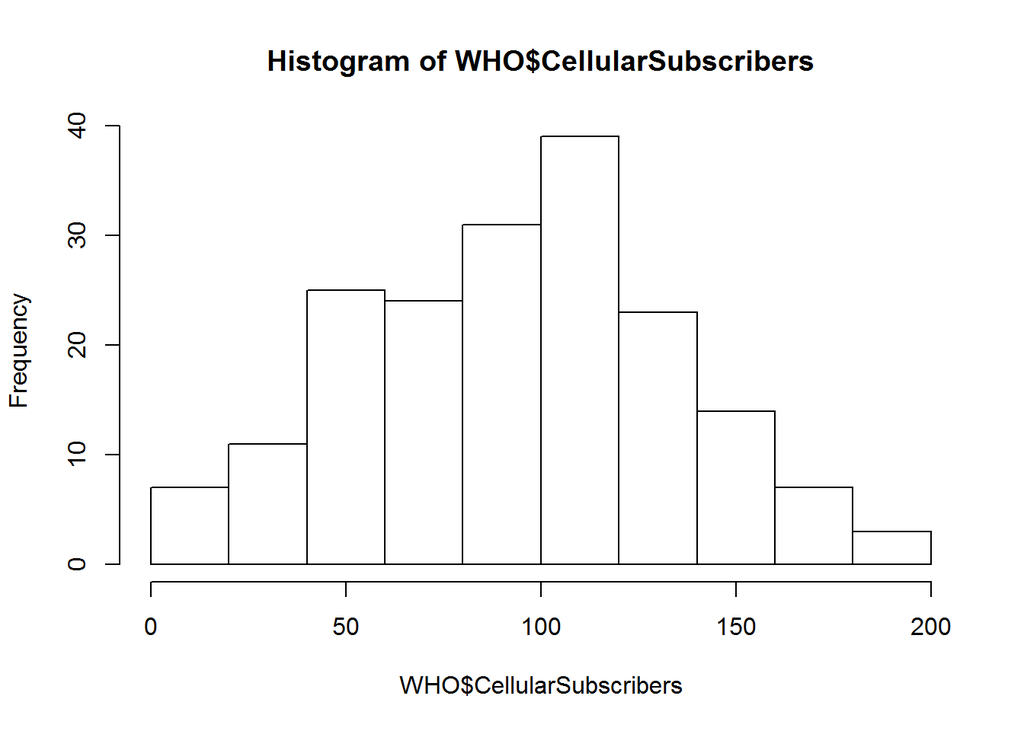

```r
# VIDEO 6

# Histograms
hist(WHO$CellularSubscribers)
```

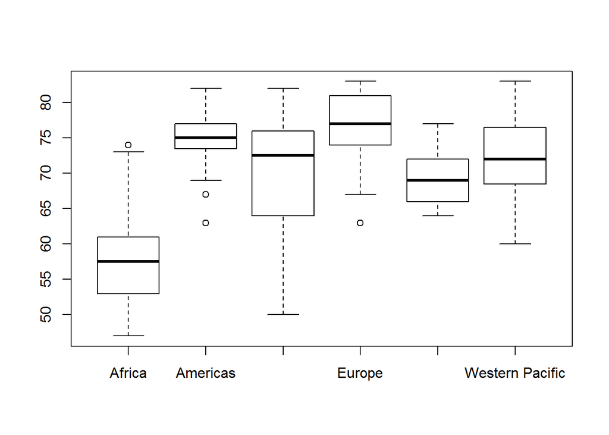

```r
# Boxplot
boxplot(WHO$LifeExpectancy ~ WHO$Region)
```

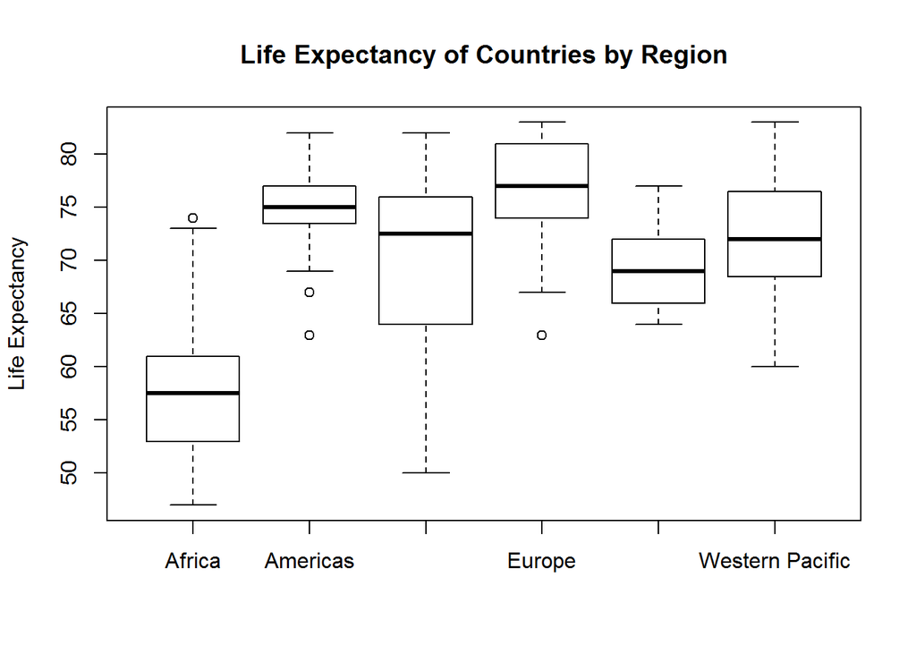

```r
boxplot(WHO$LifeExpectancy ~ WHO$Region, xlab = "", ylab = "Life Expectancy", main = "Life Expectancy of Countries by Region")
```

```r
# Summary Tables
table(WHO$Region)
```

```
##
##                Africa              Americas Eastern Mediterranean
##                    46                    35                    22
##                Europe       South-East Asia       Western Pacific
##                    53                    11                    27
```

```r
tapply(WHO$Over60, WHO$Region, mean)
```

```
##                Africa              Americas Eastern Mediterranean
##              5.220652             10.943714              5.620000
##                Europe       South-East Asia       Western Pacific
##             19.774906              8.769091             10.162963
```

```r
tapply(WHO$LiteracyRate, WHO$Region, min)
```

```
##                Africa              Americas Eastern Mediterranean
##                    NA                    NA                    NA
##                Europe       South-East Asia       Western Pacific
##                    NA                    NA                    NA
```

```r
tapply(WHO$LiteracyRate, WHO$Region, min, na.rm=TRUE)
```

```
##                Africa              Americas Eastern Mediterranean
##                  31.1                  75.2                  63.9
##                Europe       South-East Asia       Western Pacific
##                  95.2                  56.8                  60.6
```

### Understanding Food_Nutritional Education with Data(recitation)

```r
# Video 2 - Reading in the Dataset

# Get the current directory
  getwd()
```

```
## [1] "J:/rstudio files/Rstudio files_Analytics Edge_MIT"
```

```r
# Read the csv file
  USDA<-read.csv("USDA.csv")

# Structure of the dataset
  str(USDA)
```

```
## 'data.frame':    7058 obs. of  16 variables:
##  $ ID          : int  1001 1002 1003 1004 1005 1006 1007 1008 1009 1010 ...
##  $ Description : Factor w/ 7054 levels "ABALONE,MIXED SPECIES,RAW",..: 1303 1302 1298 2303 2304 2305 2306 2307 2308 2309 ...
##  $ Calories    : int  717 717 876 353 371 334 300 376 403 387 ...
##  $ Protein     : num  0.85 0.85 0.28 21.4 23.24 ...
##  $ TotalFat    : num  81.1 81.1 99.5 28.7 29.7 ...
##  $ Carbohydrate: num  0.06 0.06 0 2.34 2.79 0.45 0.46 3.06 1.28 4.78 ...
##  $ Sodium      : int  714 827 2 1395 560 629 842 690 621 700 ...
##  $ SaturatedFat: num  51.4 50.5 61.9 18.7 18.8 ...
##  $ Cholesterol : int  215 219 256 75 94 100 72 93 105 103 ...
##  $ Sugar       : num  0.06 0.06 0 0.5 0.51 0.45 0.46 NA 0.52 NA ...
##  $ Calcium     : int  24 24 4 528 674 184 388 673 721 643 ...
##  $ Iron        : num  0.02 0.16 0 0.31 0.43 0.5 0.33 0.64 0.68 0.21 ...
##  $ Potassium   : int  24 26 5 256 136 152 187 93 98 95 ...
##  $ VitaminC    : num  0 0 0 0 0 0 0 0 0 0 ...
##  $ VitaminE    : num  2.32 2.32 2.8 0.25 0.26 0.24 0.21 NA 0.29 NA ...
##  $ VitaminD    : num  1.5 1.5 1.8 0.5 0.5 0.5 0.4 NA 0.6 NA ...
```

```r
# Statistical summary
  summary(USDA)
```

```
##        ID
##  Min.   : 1001
##  1st Qu.: 8387
##  Median :13294
##  Mean   :14260
##  3rd Qu.:18337
##  Max.   :93600
##
##                                                        Description
##  BEEF,CHUCK,UNDER BLADE CNTR STEAK,BNLESS,DENVER CUT,LN,0" FA:   2
##  CAMPBELL,CAMPBELL'S SEL MICROWAVEABLE BOWLS,HEA             :   2
##  OIL,INDUSTRIAL,PALM KERNEL (HYDROGENATED),CONFECTION FAT    :   2
##  POPCORN,OIL-POPPED,LOFAT                                    :   2
##  ABALONE,MIXED SPECIES,RAW                                   :   1
##  ABALONE,MXD SP,CKD,FRIED                                    :   1
##  (Other)                                                     :7048
##     Calories        Protein         TotalFat       Carbohydrate
##  Min.   :  0.0   Min.   : 0.00   Min.   :  0.00   Min.   :  0.00
##  1st Qu.: 85.0   1st Qu.: 2.29   1st Qu.:  0.72   1st Qu.:  0.00
##  Median :181.0   Median : 8.20   Median :  4.37   Median :  7.13
##  Mean   :219.7   Mean   :11.71   Mean   : 10.32   Mean   : 20.70
##  3rd Qu.:331.0   3rd Qu.:20.43   3rd Qu.: 12.70   3rd Qu.: 28.17
##  Max.   :902.0   Max.   :88.32   Max.   :100.00   Max.   :100.00
##  NA's   :1       NA's   :1       NA's   :1        NA's   :1
##      Sodium         SaturatedFat     Cholesterol          Sugar
##  Min.   :    0.0   Min.   : 0.000   Min.   :   0.00   Min.   : 0.000
##  1st Qu.:   37.0   1st Qu.: 0.172   1st Qu.:   0.00   1st Qu.: 0.000
##  Median :   79.0   Median : 1.256   Median :   3.00   Median : 1.395
##  Mean   :  322.1   Mean   : 3.452   Mean   :  41.55   Mean   : 8.257
##  3rd Qu.:  386.0   3rd Qu.: 4.028   3rd Qu.:  69.00   3rd Qu.: 7.875
##  Max.   :38758.0   Max.   :95.600   Max.   :3100.00   Max.   :99.800
##  NA's   :84        NA's   :301      NA's   :288       NA's   :1910
##     Calcium             Iron           Potassium          VitaminC
##  Min.   :   0.00   Min.   :  0.000   Min.   :    0.0   Min.   :   0.000
##  1st Qu.:   9.00   1st Qu.:  0.520   1st Qu.:  135.0   1st Qu.:   0.000
##  Median :  19.00   Median :  1.330   Median :  250.0   Median :   0.000
##  Mean   :  73.53   Mean   :  2.828   Mean   :  301.4   Mean   :   9.436
##  3rd Qu.:  56.00   3rd Qu.:  2.620   3rd Qu.:  348.0   3rd Qu.:   3.100
##  Max.   :7364.00   Max.   :123.600   Max.   :16500.0   Max.   :2400.000
##  NA's   :136       NA's   :123       NA's   :409       NA's   :332
##     VitaminE          VitaminD
##  Min.   :  0.000   Min.   :  0.0000
##  1st Qu.:  0.120   1st Qu.:  0.0000
##  Median :  0.270   Median :  0.0000
##  Mean   :  1.488   Mean   :  0.5769
##  3rd Qu.:  0.710   3rd Qu.:  0.1000
##  Max.   :149.400   Max.   :250.0000
##  NA's   :2720      NA's   :2834
```

```r
# Video 3 - Basic Data Analysis

# Vector notation
  head(USDA$Sodium,40)
```

```
##  [1]  714  827    2 1395  560  629  842  690  621  700  604  364  344  330
## [15]  330  406  321  965 1116  800  600  819  336  800  536  627  415  619
## [29]  652  628  334 1529 1602  534  876   84  125 1200 1809  192
```

```r
# Finding the index of the food with highest sodium levels
  which.max(USDA$Sodium)
```

```
## [1] 265
```

```r
# Get names of variables in the dataset
  names(USDA)
```

```
##  [1] "ID"           "Description"  "Calories"     "Protein"
##  [5] "TotalFat"     "Carbohydrate" "Sodium"       "SaturatedFat"
##  [9] "Cholesterol"  "Sugar"        "Calcium"      "Iron"
## [13] "Potassium"    "VitaminC"     "VitaminE"     "VitaminD"
```

```r
# Get the name of the food with highest sodium levels
  USDA$Description[265]
```

```
## [1] SALT,TABLE
## 7054 Levels: ABALONE,MIXED SPECIES,RAW ... ZWIEBACK
```

```r
# Create a subset of the foods with sodium content above 10,000mg
  HighSodium<-subset(USDA, Sodium>10000)

# Count the number of rows, or observations
  nrow(HighSodium)
```

```
## [1] 10
```

```r
# Output names of the foods with high sodium content
  HighSodium$Description
```

```
##  [1] SALT,TABLE
##  [2] SOUP,BF BROTH OR BOUILLON,PDR,DRY
##  [3] SOUP,BEEF BROTH,CUBED,DRY
##  [4] SOUP,CHICK BROTH OR BOUILLON,DRY
##  [5] SOUP,CHICK BROTH CUBES,DRY
##  [6] GRAVY,AU JUS,DRY
##  [7] ADOBO FRESCO
##  [8] LEAVENING AGENTS,BAKING PDR,DOUBLE-ACTING,NA AL SULFATE
##  [9] LEAVENING AGENTS,BAKING SODA
## [10] DESSERTS,RENNIN,TABLETS,UNSWTND
## 7054 Levels: ABALONE,MIXED SPECIES,RAW ... ZWIEBACK
```

```r
# Finding the index of CAVIAR in the dataset
  match("CAVIAR", USDA$Description)
```

```
## [1] 4154
```

```r
# Find amount of sodium in caviar
  USDA$Sodium[4154]
```

```
## [1] 1500
```

```r
# Doing it in one command!
  USDA$Sodium[match("CAVIAR", USDA$Description)]
```

```
## [1] 1500
```

```r
# Summary function over Sodium vector
  summary(USDA$Sodium)
```

```
##    Min. 1st Qu.  Median    Mean 3rd Qu.    Max.    NA's
##     0.0    37.0    79.0   322.1   386.0 38760.0      84
```

```r
# Standard deviation
  sd(USDA$Sodium, na.rm = TRUE)
```

```
## [1] 1045.417
```

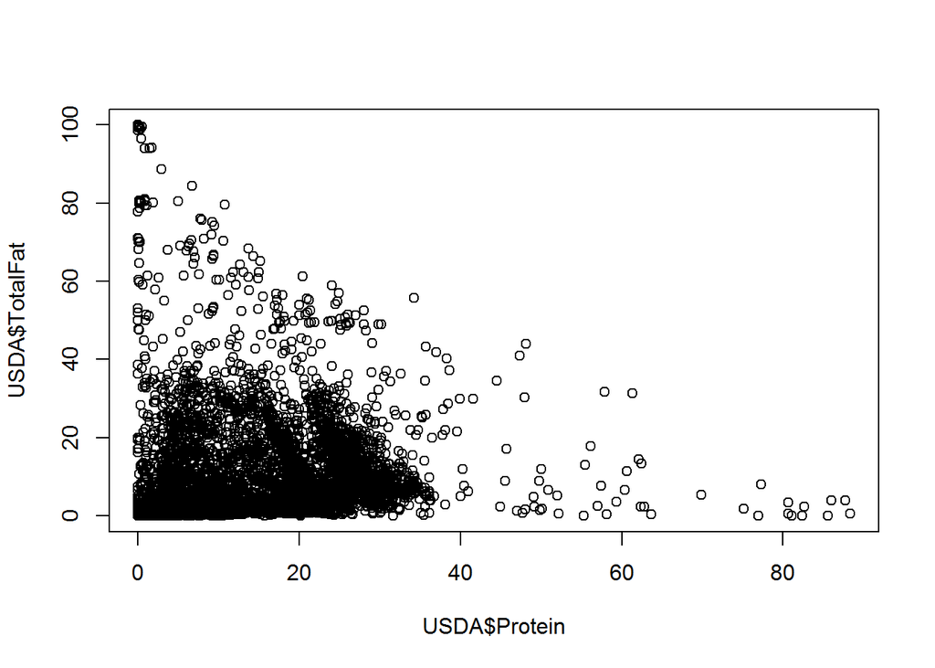

```r
# Video 4 - Plots

# Scatter Plots
  plot(USDA$Protein, USDA$TotalFat)
```

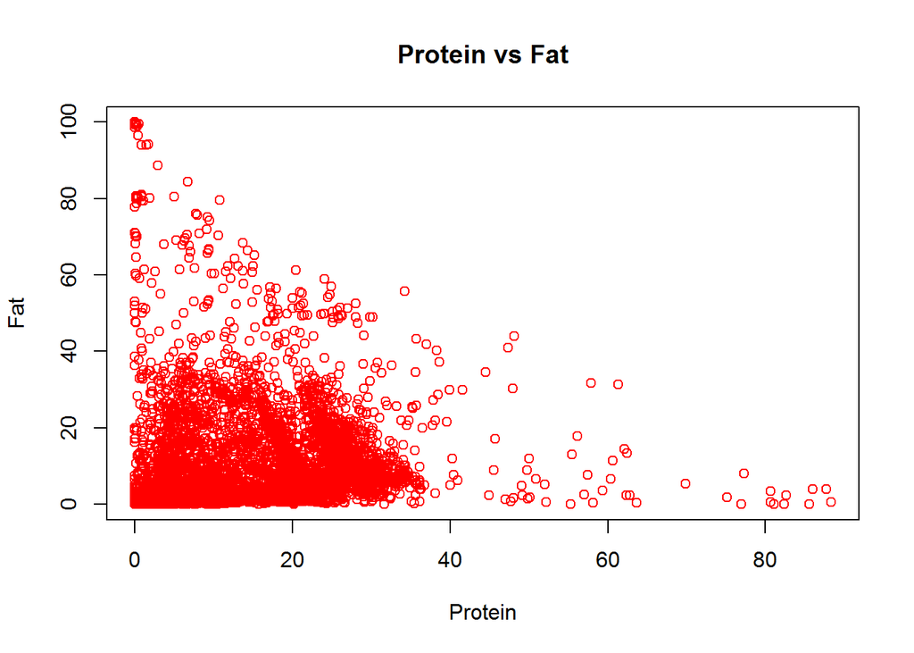

```r
# Add xlabel, ylabel and title
  plot(USDA$Protein, USDA$TotalFat, xlab="Protein", ylab = "Fat", main = "Protein vs Fat", col = "red")
```

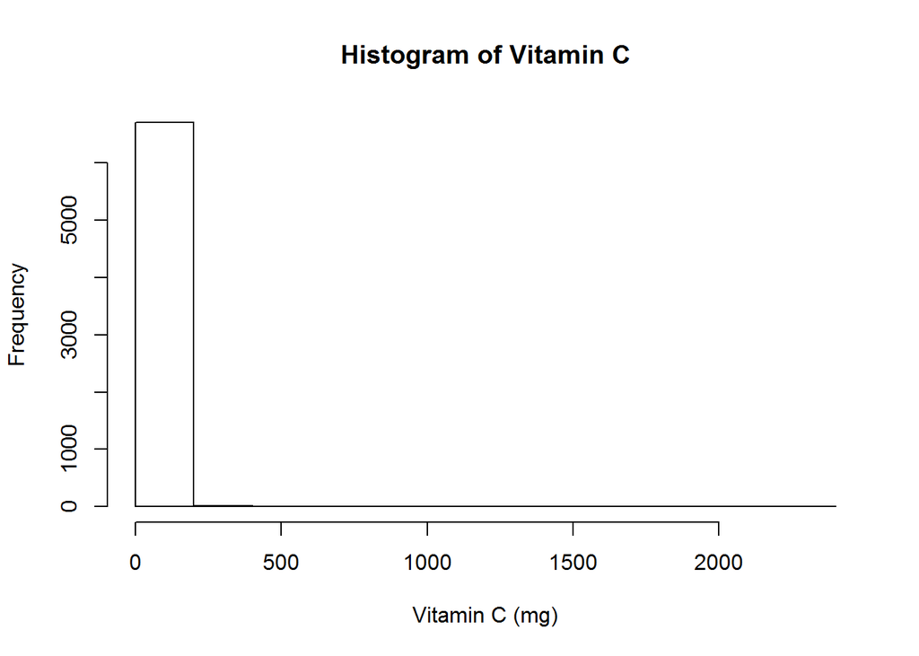

```r
# Creating a histogram
  hist(USDA$VitaminC, xlab = "Vitamin C (mg)", main = "Histogram of Vitamin C")
```

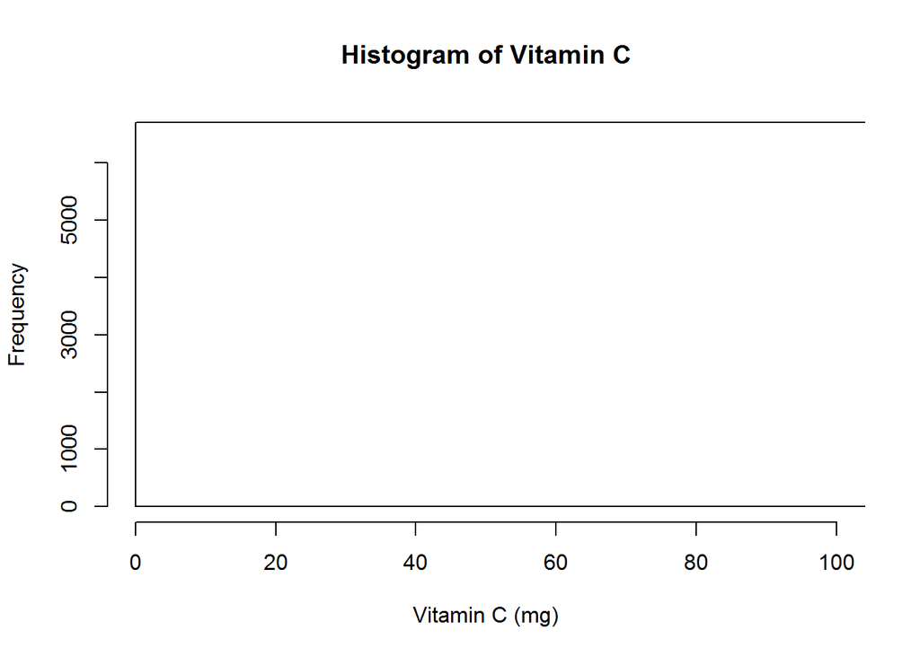

```r
# Add limits to x-axis (zooming on)
  hist(USDA$VitaminC, xlab = "Vitamin C (mg)", main = "Histogram of Vitamin C", xlim = c(0,100))
```

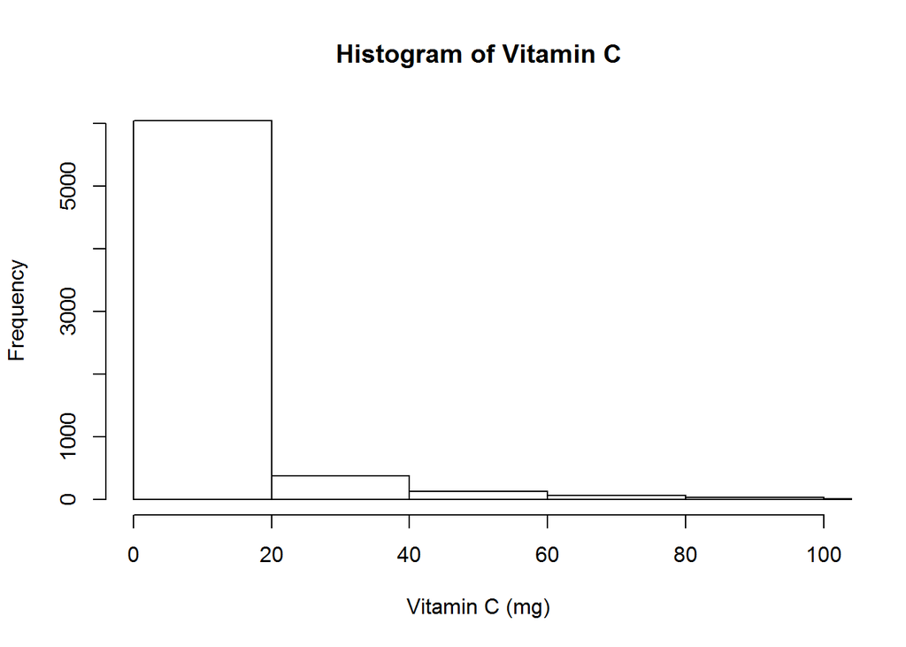

```r
# Specify breaks of histogram
  hist(USDA$VitaminC, xlab = "Vitamin C (mg)", main = "Histogram of Vitamin C", xlim = c(0,100), breaks=100)
```

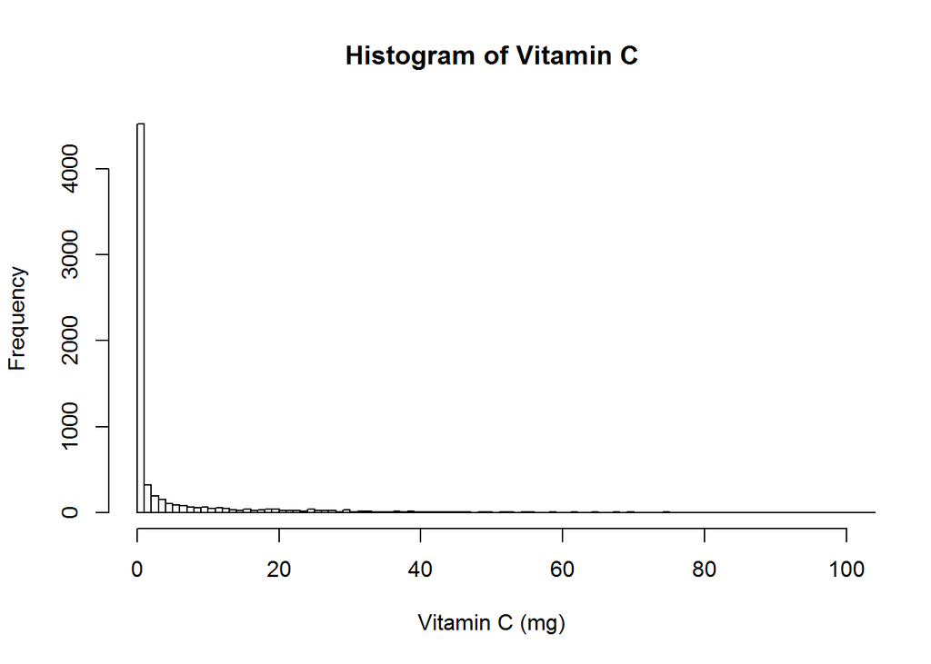

```r
  hist(USDA$VitaminC, xlab = "Vitamin C (mg)", main = "Histogram of Vitamin C", xlim = c(0,100), breaks=2000)
```

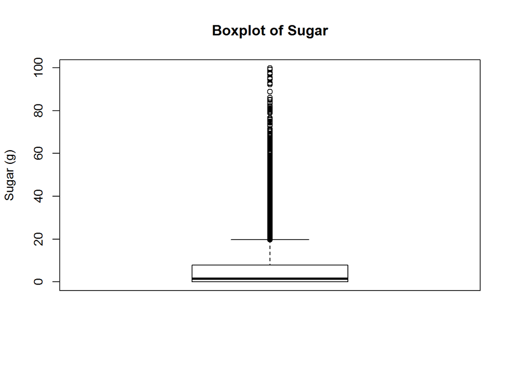

```r
# Boxplots
  boxplot(USDA$Sugar, ylab = "Sugar (g)", main = "Boxplot of Sugar")
```

```r
# Video 5 - Adding a variable

# Creating a variable that takes value 1 if the food has higher sodium than average, 0 otherwise
  HighSodium = as.numeric(USDA$Sodium > mean(USDA$Sodium, na.rm=TRUE))
  str(HighSodium)
```

```
##  num [1:7058] 1 1 0 1 1 1 1 1 1 1 ...
```

```r
# Adding the variable to the dataset
  USDA$HighSodium = as.numeric(USDA$Sodium > mean(USDA$Sodium, na.rm=TRUE))
  str(USDA) # to see if the new variable has been added to USDA dataset
```

```
## 'data.frame':    7058 obs. of  17 variables:
##  $ ID          : int  1001 1002 1003 1004 1005 1006 1007 1008 1009 1010 ...
##  $ Description : Factor w/ 7054 levels "ABALONE,MIXED SPECIES,RAW",..: 1303 1302 1298 2303 2304 2305 2306 2307 2308 2309 ...
##  $ Calories    : int  717 717 876 353 371 334 300 376 403 387 ...
##  $ Protein     : num  0.85 0.85 0.28 21.4 23.24 ...
##  $ TotalFat    : num  81.1 81.1 99.5 28.7 29.7 ...
##  $ Carbohydrate: num  0.06 0.06 0 2.34 2.79 0.45 0.46 3.06 1.28 4.78 ...
##  $ Sodium      : int  714 827 2 1395 560 629 842 690 621 700 ...
##  $ SaturatedFat: num  51.4 50.5 61.9 18.7 18.8 ...
##  $ Cholesterol : int  215 219 256 75 94 100 72 93 105 103 ...
##  $ Sugar       : num  0.06 0.06 0 0.5 0.51 0.45 0.46 NA 0.52 NA ...
##  $ Calcium     : int  24 24 4 528 674 184 388 673 721 643 ...
##  $ Iron        : num  0.02 0.16 0 0.31 0.43 0.5 0.33 0.64 0.68 0.21 ...
##  $ Potassium   : int  24 26 5 256 136 152 187 93 98 95 ...
##  $ VitaminC    : num  0 0 0 0 0 0 0 0 0 0 ...
##  $ VitaminE    : num  2.32 2.32 2.8 0.25 0.26 0.24 0.21 NA 0.29 NA ...
##  $ VitaminD    : num  1.5 1.5 1.8 0.5 0.5 0.5 0.4 NA 0.6 NA ...
##  $ HighSodium  : num  1 1 0 1 1 1 1 1 1 1 ...
```

```r
# Similarly for HighProtein, HigCarbs, HighFat
  USDA$HighCarbs = as.numeric(USDA$Carbohydrate > mean(USDA$Carbohydrate, na.rm=TRUE))
  USDA$HighProtein = as.numeric(USDA$Protein > mean(USDA$Protein, na.rm=TRUE))
  USDA$HighFat = as.numeric(USDA$TotalFat > mean(USDA$TotalFat, na.rm=TRUE))
  str(USDA) # to see if the new variable has been added to USDA dataset
```

```
## 'data.frame':    7058 obs. of  20 variables:
##  $ ID          : int  1001 1002 1003 1004 1005 1006 1007 1008 1009 1010 ...
##  $ Description : Factor w/ 7054 levels "ABALONE,MIXED SPECIES,RAW",..: 1303 1302 1298 2303 2304 2305 2306 2307 2308 2309 ...
##  $ Calories    : int  717 717 876 353 371 334 300 376 403 387 ...
##  $ Protein     : num  0.85 0.85 0.28 21.4 23.24 ...
##  $ TotalFat    : num  81.1 81.1 99.5 28.7 29.7 ...
##  $ Carbohydrate: num  0.06 0.06 0 2.34 2.79 0.45 0.46 3.06 1.28 4.78 ...
##  $ Sodium      : int  714 827 2 1395 560 629 842 690 621 700 ...
##  $ SaturatedFat: num  51.4 50.5 61.9 18.7 18.8 ...
##  $ Cholesterol : int  215 219 256 75 94 100 72 93 105 103 ...
##  $ Sugar       : num  0.06 0.06 0 0.5 0.51 0.45 0.46 NA 0.52 NA ...
##  $ Calcium     : int  24 24 4 528 674 184 388 673 721 643 ...
##  $ Iron        : num  0.02 0.16 0 0.31 0.43 0.5 0.33 0.64 0.68 0.21 ...
##  $ Potassium   : int  24 26 5 256 136 152 187 93 98 95 ...
##  $ VitaminC    : num  0 0 0 0 0 0 0 0 0 0 ...
##  $ VitaminE    : num  2.32 2.32 2.8 0.25 0.26 0.24 0.21 NA 0.29 NA ...
##  $ VitaminD    : num  1.5 1.5 1.8 0.5 0.5 0.5 0.4 NA 0.6 NA ...
##  $ HighSodium  : num  1 1 0 1 1 1 1 1 1 1 ...
##  $ HighCarbs   : num  0 0 0 0 0 0 0 0 0 0 ...
##  $ HighProtein : num  0 0 0 1 1 1 1 1 1 1 ...
##  $ HighFat     : num  1 1 1 1 1 1 1 1 1 1 ...
```

```r
# Video 6 - Summary Tables

# How many foods have higher sodium level than average?
  table(USDA$HighSodium)
```

```
##
##    0    1
## 4884 2090
```

```r
# How many foods have both high sodium and high fat?
  table(USDA$HighSodium, USDA$HighFat)
```

```
##
##        0    1
##   0 3529 1355
##   1 1378  712
```

```r
# Average amount of iron sorted by high and low protein?
  tapply(USDA$Iron, USDA$HighProtein, mean, na.rm=TRUE)
```

```
##        0        1
## 2.558945 3.197294
```

```r
# Maximum level of Vitamin C in hfoods with high and low carbs?
  tapply(USDA$VitaminC, USDA$HighCarbs, max, na.rm=TRUE)
```

```
##      0      1
## 1677.6 2400.0
```

```r
# Using summary function with tapply
  tapply(USDA$VitaminC, USDA$HighCarbs, summary, na.rm=TRUE)
```

```
## $`0`
##     Min.  1st Qu.   Median     Mean  3rd Qu.     Max.     NA's
##    0.000    0.000    0.000    6.364    2.800 1678.000      248
##
## $`1`
##    Min. 1st Qu.  Median    Mean 3rd Qu.    Max.    NA's
##    0.00    0.00    0.20   16.31    4.50 2400.00      83
```

### Assignment1:AN ANALYTICAL DETECTIVE Solution

AN ANALYTICAL DETECTIVE

Crime is an international concern, but it is documented and handled in very different ways in different countries. In the United States, violent crimes and property crimes are recorded by the Federal Bureau of Investigation (FBI). Additionally, each city documents crime, and some cities release data regarding crime rates. The city of Chicago, Illinois releases crime data from 2001 onward online.

```r
#PROBLEM 1.1 - LOADING THE DATA

#lets import the dataset
mvt<-read.csv("mvtWeek1.csv")
str(mvt)
```

```
## 'data.frame':    191641 obs. of  11 variables:
##  $ ID                 : int  8951354 8951141 8952745 8952223 8951608 8950793 8950760 8951611 8951802 8950706 ...
##  $ Date               : Factor w/ 131680 levels "1/1/01 0:01",..: 42824 42823 42823 42823 42822 42821 42820 42819 42817 42816 ...
##  $ LocationDescription: Factor w/ 78 levels "ABANDONED BUILDING",..: 72 72 62 72 72 72 72 72 72 72 ...
##  $ Arrest             : logi  FALSE FALSE FALSE FALSE FALSE TRUE ...
##  $ Domestic           : logi  FALSE FALSE FALSE FALSE FALSE FALSE ...
##  $ Beat               : int  623 1213 1622 724 211 2521 423 231 1021 1215 ...
##  $ District           : int  6 12 16 7 2 25 4 2 10 12 ...
##  $ CommunityArea      : int  69 24 11 67 35 19 48 40 29 24 ...
##  $ Year               : int  2012 2012 2012 2012 2012 2012 2012 2012 2012 2012 ...
##  $ Latitude           : num  41.8 41.9 42 41.8 41.8 ...
##  $ Longitude          : num  -87.6 -87.7 -87.8 -87.7 -87.6 ...
```

```r
summary(mvt)
```

```
##        ID                      Date
##  Min.   :1310022   5/16/08 0:00  :    11
##  1st Qu.:2832144   10/17/01 22:00:    10
##  Median :4762956   4/13/04 21:00 :    10
##  Mean   :4968629   9/17/05 22:00 :    10
##  3rd Qu.:7201878   10/12/01 22:00:     9
##  Max.   :9181151   10/13/01 22:00:     9
##                    (Other)       :191582
##                      LocationDescription   Arrest         Domestic
##  STREET                        :156564   Mode :logical   Mode :logical
##  PARKING LOT/GARAGE(NON.RESID.): 14852   FALSE:176105    FALSE:191226
##  OTHER                         :  4573   TRUE :15536     TRUE :415
##  ALLEY                         :  2308   NA's :0         NA's :0
##  GAS STATION                   :  2111
##  DRIVEWAY - RESIDENTIAL        :  1675
##  (Other)                       :  9558
##       Beat         District     CommunityArea        Year
##  Min.   : 111   Min.   : 1.00   Min.   : 0      Min.   :2001
##  1st Qu.: 722   1st Qu.: 6.00   1st Qu.:22      1st Qu.:2003
##  Median :1121   Median :10.00   Median :32      Median :2006
##  Mean   :1259   Mean   :11.82   Mean   :38      Mean   :2006
##  3rd Qu.:1733   3rd Qu.:17.00   3rd Qu.:60      3rd Qu.:2009
##  Max.   :2535   Max.   :31.00   Max.   :77      Max.   :2012
##                 NA's   :43056   NA's   :24616
##     Latitude       Longitude
##  Min.   :41.64   Min.   :-87.93
##  1st Qu.:41.77   1st Qu.:-87.72
##  Median :41.85   Median :-87.68
##  Mean   :41.84   Mean   :-87.68
##  3rd Qu.:41.92   3rd Qu.:-87.64
##  Max.   :42.02   Max.   :-87.52
##  NA's   :2276    NA's   :2276
```

```r
#How many rows of data (observations) are in this dataset?
nrow(mvt)
```

```
## [1] 191641
```

```r
#Ans:191641   #If you type str(mvt) in the R console, the first row of output says that this is a data frame with 191,641 observations.

#How many variables are in this dataset?
ncol(mvt)
```

```
## [1] 11
```

```r
#Ans:11      #If you type str(mvt) in the R console, the first row of output says that this is a data frame with 11 variables.


#Using the "max" function, what is the maximum value of the variable "ID"?
max(mvt$ID)
```

```
## [1] 9181151
```

```r
#Ans:9181151

#What is the minimum value of the variable "Beat"?
min(mvt$Beat)   # using summary(mvt$Beat)
```

```
## [1] 111
```

```r
#Ans:111

#How many observations have value TRUE in the Arrest variable (this is the number of crimes for which an arrest was made)?
table(mvt$Arrest)  # or
```

```
##
##  FALSE   TRUE
## 176105  15536
```

```r
summary(mvt$Arrest)
```

```
##    Mode   FALSE    TRUE    NA's
## logical  176105   15536       0
```

```r
#better summary function
library(Hmisc)
describe(mvt$Arrest)
```

```
## mvt$Arrest
##       n missing  unique
##  191641       0       2
##
## FALSE (176105, 92%), TRUE (15536, 8%)
```

```r
#Ans:15536

#How many observations have a LocationDescription value of ALLEY?
table(mvt$LocationDescription=="ALLEY")  # or summary(mvt)
```

```
##
##  FALSE   TRUE
## 189333   2308
```

```r
#Ans:2308

#######################################################

#PROBLEM 2.1 - UNDERSTANDING DATES IN R

#In many datasets, like this one, you have a date field. Unfortunately, R does not automatically recognize entries that look like dates. We need to use a function in R to extract the date and time. Take a look at the first entry of Date (remember to use square brackets when looking at a certain entry of a variable).

#In what format are the entries in the variable Date?
mvt$Date[1]
```

```
## [1] 12/31/12 23:15
## 131680 Levels: 1/1/01 0:01 1/1/01 0:05 1/1/01 0:30 1/1/01 1:17 ... 9/9/12 9:50
```

```r
#Ans:Month/Day/Year Hour:Minute      (12/31/12 23:15)

#Now, let's convert these characters into a Date object in R. In your R console, type
DateConvert<-as.Date(strptime(mvt$Date, "%m/%d/%y %H:%M"))
#This converts the variable "Date" into a Date object in R. Take a look at the variable DateConvert using the summary function.
summary(DateConvert)
```

```
##         Min.      1st Qu.       Median         Mean      3rd Qu.
## "2001-01-01" "2003-07-10" "2006-05-21" "2006-08-23" "2009-10-24"
##         Max.
## "2012-12-31"
```

```r
#What is the month and year of the median date in our dataset? Enter your answer as "Month Year", without the quotes. (Ex: if the answer was 2008-03-28, you would give the answer "March 2008", without the quotes.)
#Ans: May 2006

#Now, let's extract the month and the day of the week, and add these variables to our data frame mvt. We can do this with two simple functions. Type the following commands in R:
mvt$Month<-months(DateConvert)
mvt$Weekday<-weekdays(DateConvert)
#This creates two new variables in our data frame, Month and Weekday, and sets them equal to the month and weekday values that we can extract from the Date object. Lastly, replace the old Date variable with DateConvert by typing:
mvt$Date<-DateConvert

str(mvt)  # see the new var added to the mvt dataset
```

```
## 'data.frame':    191641 obs. of  13 variables:
##  $ ID                 : int  8951354 8951141 8952745 8952223 8951608 8950793 8950760 8951611 8951802 8950706 ...
##  $ Date               : Date, format: "2012-12-31" "2012-12-31" ...
##  $ LocationDescription: Factor w/ 78 levels "ABANDONED BUILDING",..: 72 72 62 72 72 72 72 72 72 72 ...
##  $ Arrest             : logi  FALSE FALSE FALSE FALSE FALSE TRUE ...
##  $ Domestic           : logi  FALSE FALSE FALSE FALSE FALSE FALSE ...
##  $ Beat               : int  623 1213 1622 724 211 2521 423 231 1021 1215 ...
##  $ District           : int  6 12 16 7 2 25 4 2 10 12 ...
##  $ CommunityArea      : int  69 24 11 67 35 19 48 40 29 24 ...
##  $ Year               : int  2012 2012 2012 2012 2012 2012 2012 2012 2012 2012 ...
##  $ Latitude           : num  41.8 41.9 42 41.8 41.8 ...
##  $ Longitude          : num  -87.6 -87.7 -87.8 -87.7 -87.6 ...
##  $ Month              : chr  "December" "December" "December" "December" ...
##  $ Weekday            : chr  "Monday" "Monday" "Monday" "Monday" ...
```

```r
#Using the table command, answer the following questions.

#In which month did the fewest motor vehicle thefts occur?
min(table(mvt$Month))
```

```
## [1] 13511
```

```r
table(mvt$Month)
```

```
##
##     April    August  December  February   January      July      June
##     15280     16572     16426     13511     16047     16801     16002
##     March       May  November   October September
##     15758     16035     16063     17086     16060
```

```r
#Ans:February

#On which weekday did the most motor vehicle thefts occur?
max(table(mvt$Weekday))
```

```
## [1] 29284
```

```r
table(mvt$Weekday)
```

```
##
##    Friday    Monday  Saturday    Sunday  Thursday   Tuesday Wednesday
##     29284     27397     27118     26316     27319     26791     27416
```

```r
#Ans:Friday

#Each observation in the dataset represents a motor vehicle theft, and the Arrest variable indicates whether an arrest was later made for this theft. Which month has the largest number of motor vehicle thefts for which an arrest was made?
max(table(mvt$Month[mvt$Arrest==TRUE]))
```

```
## [1] 1435
```

```r
table(mvt$Month[mvt$Arrest==TRUE])    # or
```

```
##
##     April    August  December  February   January      July      June
##      1252      1329      1397      1238      1435      1324      1230
##     March       May  November   October September
##      1298      1187      1256      1342      1248
```

```r
table(mvt$Arrest,mvt$Month)
```

```
##
##         April August December February January  July  June March   May
##   FALSE 14028  15243    15029    12273   14612 15477 14772 14460 14848
##   TRUE   1252   1329     1397     1238    1435  1324  1230  1298  1187
##
##         November October September
##   FALSE    14807   15744     14812
##   TRUE      1256    1342      1248
```

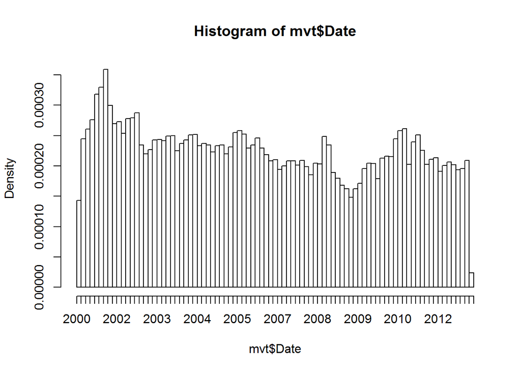

```r
#########################################################

#PROBLEM 3.1 - VISUALIZING CRIME TRENDS

#Now, let's make some plots to help us better understand how crime has changed over time in Chicago.
#First, let's make a histogram of the variable Date. We'll add an extra argument, to specify the number of bars we want in our histogram. In your R console, type
hist(mvt$Date, breaks=100)
```

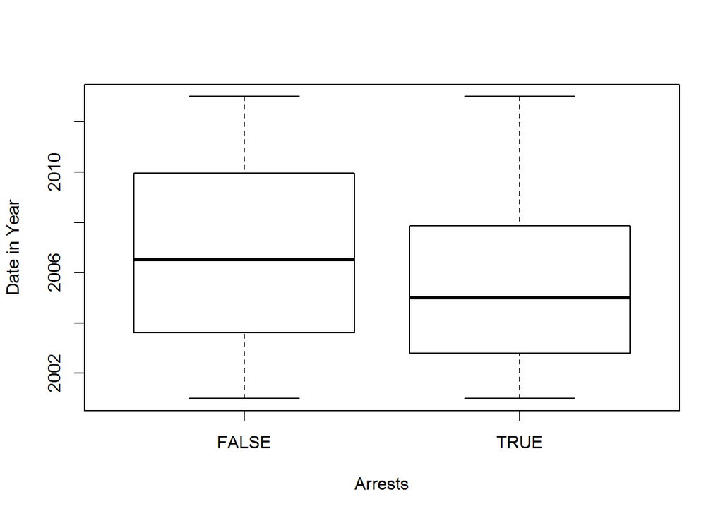

```r
#In general, does it look like crime increases or decreases from 2002 - 2012?
#Ans:decreases
#While there is not a clear trend, it looks like crime generally decreases.

#In general, does it look like crime increases or decreases from 2005 - 2008?
#Ans:Decreases
#In this time period, there is a clear downward trend in crime.

#In general, does it look like crime increases or decreases from 2009 - 2011?
#Ans:Increases
#n this time period, there is a clear upward trend in crime.

#Now, let's see how arrests have changed over time. Create a boxplot of the variable "Date", sorted by the variable "Arrest".
#Does it look like there were more crimes for which arrests were made in the first half of the time period or the second half of the time period? (Note that the time period is from 2001 to 2012, so the middle of the time period is the beginning of 2007.)
boxplot(mvt$Date~mvt$Arrest,xlab="Arrests",ylab="Date in Year")
```

```r
#Ans:First half
#If you look at the boxplot, the one for Arrest=TRUE is definitely skewed towards the bottom of the plot, meaning that there were more crimes for which arrests were made in the first half of the time period.

#For what proportion of motor vehicle thefts in 2001 was an arrest made?
prop.table(table(mvt$Arrest[mvt$Year=="2001"]))
```

```
##
##     FALSE      TRUE
## 0.8958827 0.1041173
```

```r
#Ans:0.1041173
#EXPLANATION:If you create a table using the command table(mvt$Arrest, mvt$Year), the column for 2001 has 2152 observations with Arrest=TRUE and 18517 observations with Arrest=FALSE. The fraction of motor vehicle thefts in 2001 for which an arrest was made is thus 2152/(2152+18517) = 0.1041173.

#For what proportion of motor vehicle thefts in 2007 was an arrest made?
prop.table(table(mvt$Arrest[mvt$Year=="2007"]))
```

```
##
##      FALSE       TRUE
## 0.91512605 0.08487395
```

```r
#Ans:0.08487395
#EXPLANATION:If you create a table using the command table(mvt$Arrest, mvt$Year), the column for 2007 has 1212 observations with Arrest=TRUE and 13068 observations with Arrest=FALSE. The fraction of motor vehicle thefts in 2007 for which an arrest was made is thus 1212/(1212+13068) = 0.08487395.

#For what proportion of motor vehicle thefts in 2012 was an arrest made?
prop.table(table(mvt$Arrest[mvt$Year=="2012"]))
```

```
##
##      FALSE       TRUE
## 0.96097076 0.03902924
```

```r
#Ans:0.03902924
#EXPLANATION:If you create a table using the command table(mvt$Arrest, mvt$Year), the column for 2012 has 550 observations with Arrest=TRUE and 13542 observations with Arrest=FALSE. The fraction of motor vehicle thefts in 2012 for which an arrest was made is thus 550/(550+13542) = 0.03902924.

#########################################

#PROBLEM 4.1 - POPULAR LOCATIONS

#Analyzing this data could be useful to the Chicago Police Department when deciding where to allocate resources. If they want to increase the number of arrests that are made for motor vehicle thefts, where should they focus their efforts?We want to find the top five locations where motor vehicle thefts occur. If you create a table of the LocationDescription variable, it is unfortunately very hard to read since there are 78 different locations in the data set. By using the sort function, we can view this same table, but sorted by the number of observations in each category. In your R console, type:
sort(table(mvt$LocationDescription))
```

```
##
##     AIRPORT BUILDING NON-TERMINAL - SECURE AREA
##                                               1
##                  AIRPORT EXTERIOR - SECURE AREA
##                                               1
##                                 ANIMAL HOSPITAL
##                                               1
##                                 APPLIANCE STORE
##                                               1
##                                       CTA TRAIN
##                                               1
##                         JAIL / LOCK-UP FACILITY
##                                               1
##                                       NEWSSTAND
##                                               1
##                                          BRIDGE
##                                               2
##               COLLEGE/UNIVERSITY RESIDENCE HALL
##                                               2
##                               CURRENCY EXCHANGE
##                                               2
##                                   BOWLING ALLEY
##                                               3
##                                  CLEANING STORE
##                                               3
##                           MEDICAL/DENTAL OFFICE
##                                               3
##                              ABANDONED BUILDING
##                                               4
## AIRPORT BUILDING NON-TERMINAL - NON-SECURE AREA
##                                               4
##                                      BARBERSHOP
##                                               4
##                  LAKEFRONT/WATERFRONT/RIVERBANK
##                                               4
##                                         LIBRARY
##                                               4
##                                SAVINGS AND LOAN
##                                               4
##  AIRPORT TERMINAL UPPER LEVEL - NON-SECURE AREA
```

[output cut: 102 more lines]

```
##                                            1302
##                   RESIDENTIAL YARD (FRONT/BACK)
##                                            1536
##                          DRIVEWAY - RESIDENTIAL
##                                            1675
##                                     GAS STATION
##                                            2111
##                                           ALLEY
##                                            2308
##                                           OTHER
##                                            4573
##                  PARKING LOT/GARAGE(NON.RESID.)
##                                           14852
##                                          STREET
##                                          156564
```

```r
#Which locations are the top five locations for motor vehicle thefts, excluding the "Other" category? You should select 5 of the following options.
#Ans:Street, Parking Lot/Garage (Non. Resid.), Alley, Gas Station, and Driveway - Residential

#Create a subset of your data, only taking observations for which the theft happened in one of these five locations, and call this new data set "Top5". To do this, you can use the | symbol. In lecture, we used the & symbol to use two criteria to make a subset of the data. To only take observations that have a certain value in one variable or the other, the | character can be used in place of the & symbol. This is also called a logical "or" operation.

#How many observations are in Top5?
Top5<-mvt[mvt$LocationDescription %in%  c("STREET","ALLEY","PARKING LOT/GARAGE(NON.RESID.)","GAS STATION","DRIVEWAY - RESIDENTIAL"),]

#or

TopLocations<-c("STREET", "PARKING LOT/GARAGE(NON.RESID.)", "ALLEY", "GAS STATION", "DRIVEWAY - RESIDENTIAL")

Top5<-subset(mvt, LocationDescription %in% TopLocations)

#or

Top5<-subset(mvt, LocationDescription=="STREET" | LocationDescription=="PARKING LOT/GARAGE(NON.RESID.)" | LocationDescription=="ALLEY" | LocationDescription=="GAS STATION" | LocationDescription=="DRIVEWAY - RESIDENTIAL")

str(Top5)
```

```
## 'data.frame':    177510 obs. of  13 variables:
##  $ ID                 : int  8951354 8951141 8952223 8951608 8950793 8950760 8951611 8951802 8950706 8951585 ...
##  $ Date               : Date, format: "2012-12-31" "2012-12-31" ...
##  $ LocationDescription: Factor w/ 78 levels "ABANDONED BUILDING",..: 72 72 72 72 72 72 72 72 72 72 ...
##  $ Arrest             : logi  FALSE FALSE FALSE FALSE TRUE FALSE ...
##  $ Domestic           : logi  FALSE FALSE FALSE FALSE FALSE FALSE ...
##  $ Beat               : int  623 1213 724 211 2521 423 231 1021 1215 1011 ...
##  $ District           : int  6 12 7 2 25 4 2 10 12 10 ...
##  $ CommunityArea      : int  69 24 67 35 19 48 40 29 24 29 ...
##  $ Year               : int  2012 2012 2012 2012 2012 2012 2012 2012 2012 2012 ...
##  $ Latitude           : num  41.8 41.9 41.8 41.8 41.9 ...
##  $ Longitude          : num  -87.6 -87.7 -87.7 -87.6 -87.8 ...
##  $ Month              : chr  "December" "December" "December" "December" ...
##  $ Weekday            : chr  "Monday" "Monday" "Monday" "Monday" ...
```

```r
margin.table(sort(table(Top5$LocationDescription)))
```

```
## [1] 177510
```

```r
#Ans:177510

#####################################################

#R will remember the other categories of the LocationDescription variable from the original dataset, so running table(Top5$LocationDescription) will have a lot of unnecessary output. To make our tables a bit nicer to read, we can refresh this factor variable. In your R console, type:

Top5$LocationDescription<-factor(Top5$LocationDescription)

#If you run the str or table function on Top5 now, you should see that LocationDescription now only has 5 values, as we expect.
str(Top5)
```

```
## 'data.frame':    177510 obs. of  13 variables:
##  $ ID                 : int  8951354 8951141 8952223 8951608 8950793 8950760 8951611 8951802 8950706 8951585 ...
##  $ Date               : Date, format: "2012-12-31" "2012-12-31" ...
##  $ LocationDescription: Factor w/ 5 levels "ALLEY","DRIVEWAY - RESIDENTIAL",..: 5 5 5 5 5 5 5 5 5 5 ...
##  $ Arrest             : logi  FALSE FALSE FALSE FALSE TRUE FALSE ...
##  $ Domestic           : logi  FALSE FALSE FALSE FALSE FALSE FALSE ...
##  $ Beat               : int  623 1213 724 211 2521 423 231 1021 1215 1011 ...
##  $ District           : int  6 12 7 2 25 4 2 10 12 10 ...
##  $ CommunityArea      : int  69 24 67 35 19 48 40 29 24 29 ...
##  $ Year               : int  2012 2012 2012 2012 2012 2012 2012 2012 2012 2012 ...
##  $ Latitude           : num  41.8 41.9 41.8 41.8 41.9 ...
##  $ Longitude          : num  -87.6 -87.7 -87.7 -87.6 -87.8 ...
##  $ Month              : chr  "December" "December" "December" "December" ...
##  $ Weekday            : chr  "Monday" "Monday" "Monday" "Monday" ...
```

```r
table(Top5$LocationDescription)
```

```
##
##                          ALLEY         DRIVEWAY - RESIDENTIAL
##                           2308                           1675
##                    GAS STATION PARKING LOT/GARAGE(NON.RESID.)
##                           2111                          14852
##                         STREET
##                         156564
```

```r
#Use the Top5 data frame to answer the remaining questions.

#One of the locations has a much higher arrest rate than the other locations. Which is it? Please enter the text in exactly the same way as how it looks in the answer options for Problem 4.1.
table(Top5$LocationDescription, Top5$Arrest)
```

```
##
##                                   FALSE   TRUE
##   ALLEY                            2059    249
##   DRIVEWAY - RESIDENTIAL           1543    132
##   GAS STATION                      1672    439
##   PARKING LOT/GARAGE(NON.RESID.)  13249   1603
##   STREET                         144969  11595
```

```r
prop.table(table(Top5$LocationDescription, Top5$Arrest),1)#calculation prop. row-wise
```

```
##
##                                       FALSE       TRUE
##   ALLEY                          0.89211438 0.10788562
##   DRIVEWAY - RESIDENTIAL         0.92119403 0.07880597
##   GAS STATION                    0.79204169 0.20795831
##   PARKING LOT/GARAGE(NON.RESID.) 0.89206841 0.10793159
##   STREET                         0.92594083 0.07405917
```

```r
#Ans:Gas Station
#EXPLANATION:If you create a table of LocationDescription compared to Arrest, table(Top5$LocationDescription, Top5$Arrest), you can then compute the fraction of motor vehicle thefts that resulted in arrests at each location. Gas Station has by far the highest percentage of arrests, with over 20% of motor vehicle thefts resulting in an arrest.

#On which day of the week do the most motor vehicle thefts at gas stations happen?
max(table(Top5$Weekday[Top5$LocationDescription=="GAS STATION"])) # to find the max value
```

```
## [1] 338
```

```r
table(Top5$Weekday[Top5$LocationDescription=="GAS STATION"])
```

```
##
##    Friday    Monday  Saturday    Sunday  Thursday   Tuesday Wednesday
##       332       280       338       336       282       270       273
```

```r
#Ans:Saturday
#EXPLANATION:This can be read from table(Top5$LocationDescription, Top5$Weekday).
table(Top5$LocationDescription,Top5$Weekday)
```

```
##
##                                  Friday Monday Saturday Sunday Thursday
##   ALLEY                             385    320      341    307      315
##   DRIVEWAY - RESIDENTIAL            257    255      202    221      263
##   GAS STATION                       332    280      338    336      282
##   PARKING LOT/GARAGE(NON.RESID.)   2331   2128     2199   1936     2082
##   STREET                          23773  22305    22175  21756    22296
##
##                                  Tuesday Wednesday
##   ALLEY                              323       317
##   DRIVEWAY - RESIDENTIAL             243       234
##   GAS STATION                        270       273
##   PARKING LOT/GARAGE(NON.RESID.)    2073      2103
##   STREET                           21888     22371
```

```r
#On which day of the week do the fewest motor vehicle thefts in residential driveways happen?
min(table(Top5$Weekday[Top5$LocationDescription=="DRIVEWAY - RESIDENTIAL"])) # to find the min value
```

```
## [1] 202
```

```r
table(Top5$Weekday[Top5$LocationDescription=="DRIVEWAY - RESIDENTIAL"])
```

```
##
##    Friday    Monday  Saturday    Sunday  Thursday   Tuesday Wednesday
##       257       255       202       221       263       243       234
```

```r
#Ans:Saturday
```

### Assignment1:STOCK DYNAMICS Solution

A stock market is where buyers and sellers trade shares of a company, and is one of the most popular ways for individuals and companies to invest money. The size of the world stock market is now estimated to be in the trillions. The largest stock market in the world is the New York Stock Exchange (NYSE), located in New York City. About 2,800 companies are listed on the NSYE. In this problem, we’ll look at the monthly stock prices of five of these companies: IBM, General Electric (GE), Procter and Gamble, Coca Cola, and Boeing. The data used in this problem comes from Infochimps.

**In this problem, we’ll take a look at how the stock dynamics of these companies have changed over time.**

```r
#Lets  import the datasets

IBM<-read.csv("IBMStock.csv")
GE<-read.csv("GEStock.csv")
ProcterGamble<-read.csv("ProcterGambleStock.csv")
CocaCola<-read.csv("CocaColaStock.csv")
Boeing<-read.csv("BoeingStock.csv")

#PROBLEM 1.1 - SUMMARY STATISTICS

#Before working with these data sets, we need to convert the dates into a format that R can understand. Take a look at the structure of one of the datasets using the str function. Right now, the date variable is stored as a factor.
str(IBM)
```

```
## 'data.frame':    480 obs. of  2 variables:
##  $ Date      : Factor w/ 480 levels "1/1/00","1/1/01",..: 11 171 211 251 291 331 371 411 451 51 ...
##  $ StockPrice: num  360 347 327 320 270 ...
```

```r
head(IBM)
```

```
##     Date StockPrice
## 1 1/1/70   360.3190
## 2 2/1/70   346.7237
## 3 3/1/70   327.3457
## 4 4/1/70   319.8527
## 5 5/1/70   270.3752
## 6 6/1/70   267.2050
```

```r
IBM$Date[1]
```

```
## [1] 1/1/70
## 480 Levels: 1/1/00 1/1/01 1/1/02 1/1/03 1/1/04 1/1/05 1/1/06 ... 9/1/99
```

```r
#We can convert this to a "Date" object in R by using the following five commands (one for each data set):

IBM$Date<-as.Date(IBM$Date, "%m/%d/%y")

GE$Date<-as.Date(GE$Date, "%m/%d/%y")

CocaCola$Date<-as.Date(CocaCola$Date, "%m/%d/%y")

ProcterGamble$Date<-as.Date(ProcterGamble$Date, "%m/%d/%y")

Boeing$Date<-as.Date(Boeing$Date, "%m/%d/%y")

#Our five datasets all have the same number of observations. How many observations are there in each data set?
str(GE)
```

```
## 'data.frame':    480 obs. of  2 variables:
##  $ Date      : Date, format: "1970-01-01" "1970-02-01" ...
##  $ StockPrice: num  74.3 70 72.2 74.3 66.7 ...
```

```r
#Ans:480
#EXPLANATION:Using the str function, we can see that each data set has 480 observations. We have monthly data for 40 years, so there are 12*40 = 480 observations.

#What is the earliest year in our datasets?
summary(IBM)   # or head(sort(IBM$Date))
```

```
##       Date              StockPrice
##  Min.   :1970-01-01   Min.   : 43.40
##  1st Qu.:1979-12-24   1st Qu.: 88.34
##  Median :1989-12-16   Median :112.11
##  Mean   :1989-12-15   Mean   :144.38
##  3rd Qu.:1999-12-08   3rd Qu.:165.41
##  Max.   :2009-12-01   Max.   :438.90
```

```r
#Ans:1970

#What is the latest year in our datasets?
summary(GE)
```

```
##       Date              StockPrice
##  Min.   :1970-01-01   Min.   :  9.294
##  1st Qu.:1979-12-24   1st Qu.: 44.214
##  Median :1989-12-16   Median : 55.812
##  Mean   :1989-12-15   Mean   : 59.303
##  3rd Qu.:1999-12-08   3rd Qu.: 72.226
##  Max.   :2009-12-01   Max.   :156.844
```

```r
#Ans:2009

#What is the mean stock price of IBM over this time period?
mean(IBM$StockPrice)   # or  summary(IBM)
```

```
## [1] 144.375
```

```r
#Ans:144.375

#What is the minimum stock price of General Electric (GE) over this time period?
min(GE$StockPrice)  #or summary(GE)
```

```
## [1] 9.293636
```

```r
#Ans:9.293636

#What is the maximum stock price of Coca-Cola over this time period?
max(CocaCola$StockPrice)  #or summary(CocaCola)
```

```
## [1] 146.5843
```

```r
#Ans:146.5843

#What is the median stock price of Boeing over this time period?
median((Boeing$StockPrice))  #or summary(Boeing)
```

```
## [1] 44.8834
```

```r
#Ans:44.8834

#What is the standard deviation of the stock price of Procter & Gamble over this time period?
sd(ProcterGamble$StockPrice)
```

```
## [1] 18.19414
```

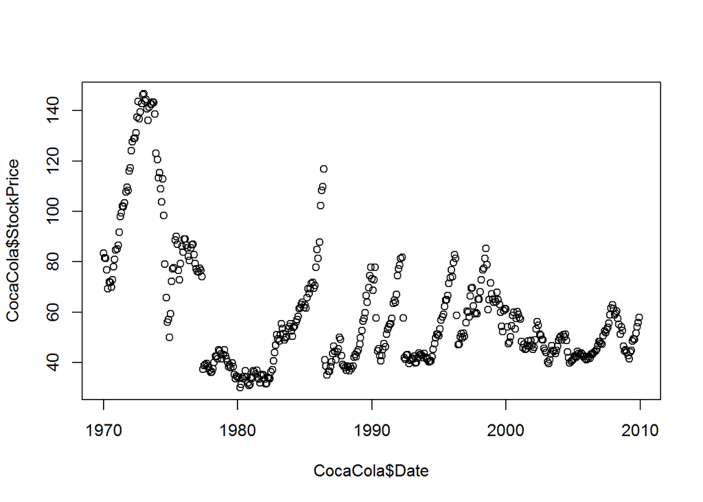

```r
#Ans:18.19414

####################################################

#PROBLEM 2.1 - VISUALIZING STOCK DYNAMICS

#Let's plot the stock prices to see if we can visualize trends in stock prices during this time period. Using the plot function, plot the Date on the x-axis and the StockPrice on the y-axis, for Coca-Cola.

plot(CocaCola$Date,CocaCola$StockPrice)
```

```r
#This plots our observations as points, but we would really like to see a line instead, since this is a continuous time period. To do this, add the argument type="l" to your plot command, and re-generate the plot (the character is quotes is the letter l, for line). You should now see a line plot of the Coca-Cola stock price.

plot(CocaCola$Date,CocaCola$StockPrice,type="l")

#Around what year did Coca-Cola has its highest stock price in this time period?
CocaCola$Date[which.max(CocaCola$StockPrice)]
```

```
## [1] "1973-01-01"
```

```r
#Ans:1973


#Around what year did Coca-Cola has its lowest stock price in this time period?
CocaCola$Date[which.min(CocaCola$StockPrice)]
```

```
## [1] "1980-03-01"
```

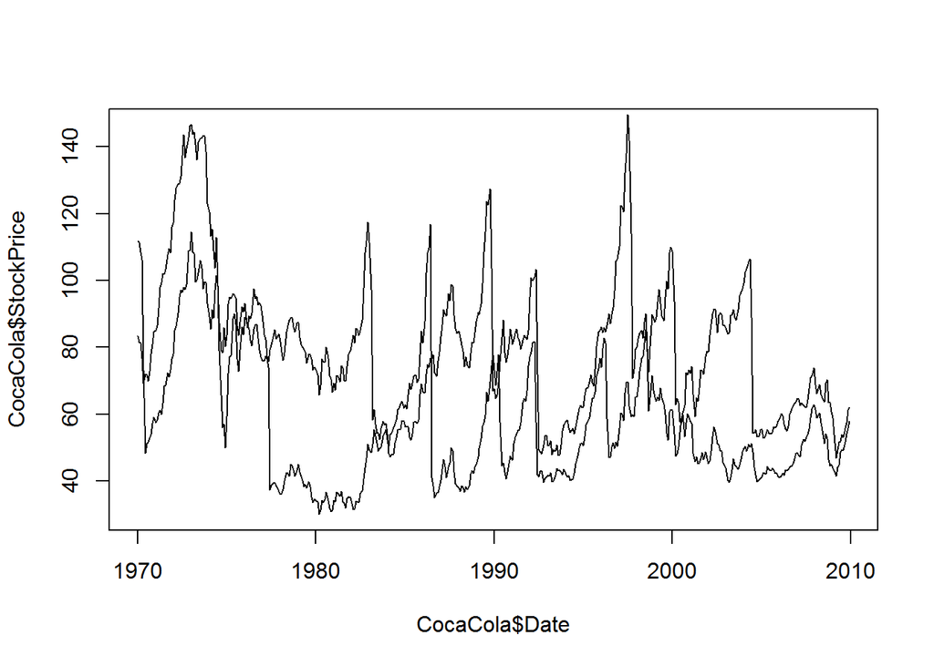

```r
#Ans:1980

#Now, let's add the line for Procter & Gamble too. You can add a line to a plot in R by using the lines function instead of the plot function. Keeping the plot for Coca-Cola open, type in your R console:

lines(ProcterGamble$Date, ProcterGamble$StockPrice)
```

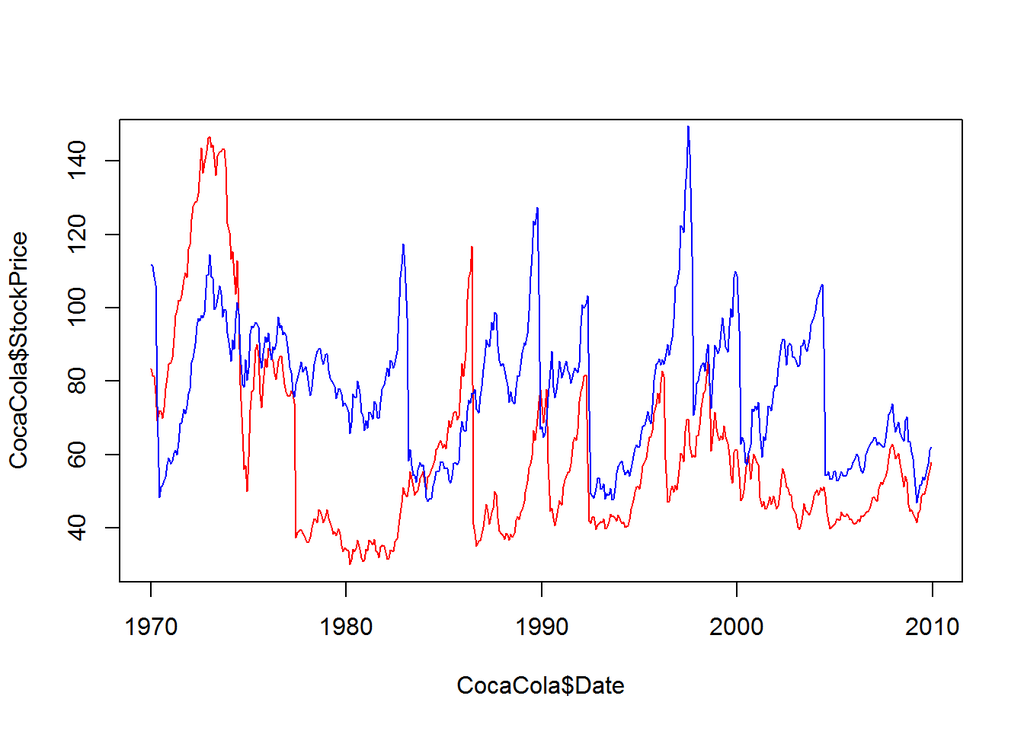

```r
#Unfortunately, it's hard to tell which line is which. Let's fix this by giving each line a color. First, re-run the plot command for Coca-Cola, but add the argument col="red".
plot(CocaCola$Date,CocaCola$StockPrice,type="l",col="red")
#You should see the plot for Coca-Cola show up again, but this time in red. Now, let's add the Procter & Gamble line (using the lines function like we did before), adding the argument col="blue". You should now see in your plot the Coca-Cola stock price in red, and the Procter & Gamble stock price in blue.
lines(ProcterGamble$Date, ProcterGamble$StockPrice,col="blue")
```

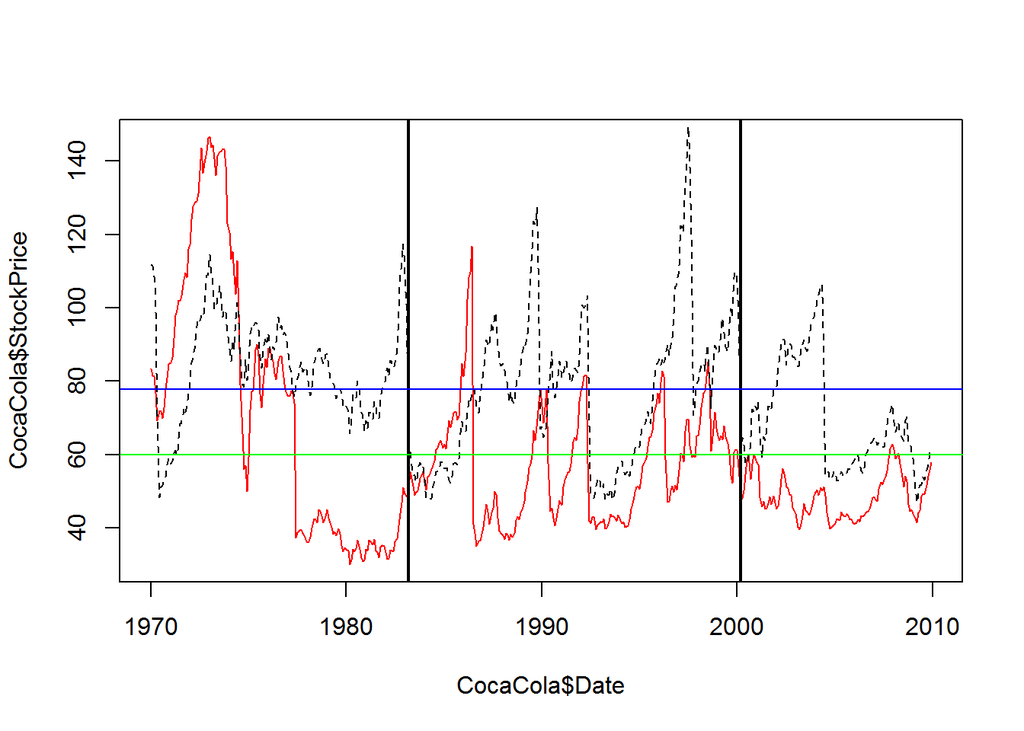

```r
#As an alternative choice to changing the colors, you could instead change the line type of the Procter & Gamble line by adding the argument lty=2. This will make the Procter & Gamble line dashed.
plot(CocaCola$Date,CocaCola$StockPrice,type="l",col="red")
lines(ProcterGamble$Date, ProcterGamble$StockPrice,lty=2)
abline(v=as.Date(c("2000-03-01")), lwd=2)

#In March of 2000, the technology bubble burst, and a stock market crash occurred. According to this plot, which company's stock dropped more?
#Ans:Procter and Gamble

#Around 1983, the stock for one of these companies (Coca-Cola or Procter and Gamble) was going up, while the other was going down. Which one was going up?
abline(v=as.Date(c("1983-03-01")), lwd=2)
#Ans:Coca-Cola

#In the time period shown in the plot, which stock generally has lower values?
abline(h=mean(CocaCola$StockPrice),col="green")
abline(h=mean(ProcterGamble$StockPrice),col="blue")
```

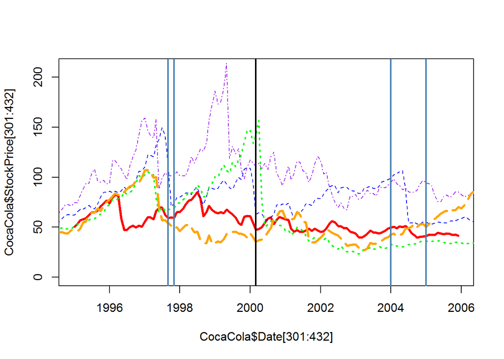

```r
#Ans:Coca-Cola

##############################################

#PROBLEM 3.1 - VISUALIZING STOCK DYNAMICS 1995-2005

#Let's take a look at how the stock prices changed from 1995-2005 for all five companies. In your R console, start by typing the following plot command:
plot(CocaCola$Date[301:432], CocaCola$StockPrice[301:432], type="l", col="red", ylim=c(0,210),lwd=3)
#This will plot the CocaCola stock prices from 1995 through 2005, which are the observations numbered from 301 to 432. The additional argument, ylim=c(0,210), makes the y-axis range from 0 to 210. This will allow us to see all of the stock values when we add in the other companies.

#Now, use the lines function to add in the other four companies, remembering to only plot the observations from 1995 to 2005, or [301:432]. You don't need the "type" or "ylim" arguments for the lines function, but remember to make each company a different color so that you can tell them apart. Some color options are "red", "blue", "green", "purple", "orange", and "black". To see all of the color options in R, type colors() in your R console.
lines(ProcterGamble$Date, ProcterGamble$StockPrice,lty=2,col="blue")
lines(GE$Date,GE$StockPrice,lty=3,col="green",lwd=2)
lines(IBM$Date,IBM$StockPrice,col="purple",lty=4)
lines(Boeing$Date,Boeing$StockPrice,col="orange",lty=5,lwd=3)
#If you prefer to change the type of the line instead of the color, here are some options for changing the line type: lty=2 will make the line dashed, lty=3 will make the line dotted, lty=4 will make the line alternate between dashes and dots, and lty=5 will make the line long-dashed.

#Which stock fell the most right after the technology bubble burst in March 2000?
abline(v=as.Date(c("2000-03-01")), lwd=2)
#Ans:GE

#Which stock reaches the highest value in the time period 1995-2005?
#Ans:IBM

#In October of 1997, there was a global stock market crash that was caused by an economic crisis in Asia. Comparing September 1997 to November 1997, which companies saw a decreasing trend in their stock price? (Select all that apply.)
abline(v=as.Date(c("1997-09-01")), lwd=2,col="steelblue")
abline(v=as.Date(c("1997-11-01")), lwd=2,col="steelblue")
#Ans:Boeing and Procter & Gamble

#In the last two years of this time period (2004 and 2005) which stock seems to be performing the best, in terms of increasing stock price?
abline(v=as.Date(c("2004-01-01")), lwd=2,col="steelblue")
abline(v=as.Date(c("2005-01-01")), lwd=2,col="steelblue")
```

```r
#Ans:Boeing

###########################################

#PROBLEM 4.1 - MONTHLY TRENDS

#Lastly, let's see if stocks tend to be higher or lower during certain months. Use the tapply command to calculate the mean stock price of IBM, sorted by months. To sort by months, use months(IBM$Date) as the second argument of the tapply function.
tapply(IBM$StockPrice,months(IBM$Date),mean)
```

```
##     April    August  December  February   January      July      June
##  152.1168  140.1455  140.7593  152.6940  150.2384  139.0670  139.0907
##     March       May  November   October September
##  152.4327  151.5022  138.0187  137.3466  139.0885
```

```r
#For IBM, compare the monthly averages to the overall average stock price. In which months has IBM historically had a higher stock price (on average)? Select all that apply.
tapply(IBM$StockPrice,months(IBM$Date),mean)>mean(IBM$StockPrice)
```

```
##     April    August  December  February   January      July      June
##      TRUE     FALSE     FALSE      TRUE      TRUE     FALSE     FALSE
##     March       May  November   October September
##      TRUE      TRUE     FALSE     FALSE     FALSE
```

```r
#Ans:January to May

#Repeat the tapply function from the previous problem for each of the other four companies, and use the output to answer the remaining questions.
tapply(GE$StockPrice,months(GE$Date),mean)
```

```
##     April    August  December  February   January      July      June
##  64.48009  56.50315  59.10217  62.52080  62.04511  56.73349  56.46844
##     March       May  November   October September
##  63.15055  60.87135  57.28879  56.23897  56.23913
```

```r
tapply(ProcterGamble$StockPrice,months(ProcterGamble$Date),mean)
```

```
##     April    August  December  February   January      July      June
##  77.68671  76.82266  78.29661  79.02575  79.61798  76.64556  77.39275
##     March       May  November   October September
##  77.34761  77.85958  78.45610  76.67903  76.62385
```

```r
tapply(Boeing$StockPrice,months(Boeing$Date),mean)
```

```
##     April    August  December  February   January      July      June
##  47.04686  46.86311  46.17315  46.89223  46.51097  46.55360  47.38525
##     March       May  November   October September
##  46.88208  48.13716  45.14990  45.21603  46.30485
```

```r
tapply(CocaCola$StockPrice,months(CocaCola$Date),mean)
```

```
##     April    August  December  February   January      July      June
##  62.68888  58.88014  59.73223  60.73475  60.36849  58.98346  60.81208
##     March       May  November   October September
##  62.07135  61.44358  59.10268  57.93887  57.60024
```

```r
#General Electric and Coca-Cola both have their highest average stock price in the same month. Which month is this?
which.max(tapply(GE$StockPrice,months(GE$Date),mean))
```

```
## April
##     1
```

```r
which.max(tapply(CocaCola$StockPrice,months(CocaCola$Date),mean))
```

```
## April
##     1
```

```r
#Ans:April

#For the months of December and January, every company's average stock is higher in one month and lower in the other. In which month are the stock prices lower?
#Ans:December
```

### Assignment1:DEMOGRAPHICS AND EMPLOYMENT IN THE UNITED STATES solution

In the wake of the Great Recession of 2009, there has been a good deal of focus on employment statistics, one of the most important metrics policymakers use to gauge the overall strength of the economy. In the United States, the government measures unemployment using the Current Population Survey (CPS), which collects demographic and employment information from a wide range of Americans each month. In this exercise, we will employ the topics reviewed in the lectures as well as a few new techniques using the September 2013 version of this rich, nationally representative dataset ([available online](http://thedataweb.rm.census.gov/ftp/cps_ftp.html)).

The observations in the dataset represent people surveyed in the September 2013 CPS who actually completed a survey. While the full dataset has 385 variables, in this exercise we will use a more compact version of the dataset, CPSData.csv

```r
#PROBLEM 1.1 - LOADING AND SUMMARIZING THE DATASET

#Lets import the dataset
CPS<-read.csv("CPSData.csv")
str(CPS)
```

```
## 'data.frame':    131302 obs. of  14 variables:
##  $ PeopleInHousehold : int  1 3 3 3 3 3 3 2 2 2 ...
##  $ Region            : Factor w/ 4 levels "Midwest","Northeast",..: 3 3 3 3 3 3 3 3 3 3 ...
##  $ State             : Factor w/ 51 levels "Alabama","Alaska",..: 1 1 1 1 1 1 1 1 1 1 ...
##  $ MetroAreaCode     : int  26620 13820 13820 13820 26620 26620 26620 33660 33660 26620 ...
##  $ Age               : int  85 21 37 18 52 24 26 71 43 52 ...
##  $ Married           : Factor w/ 5 levels "Divorced","Married",..: 5 3 3 3 5 3 3 1 1 3 ...
##  $ Sex               : Factor w/ 2 levels "Female","Male": 1 2 1 2 1 2 2 1 2 2 ...
##  $ Education         : Factor w/ 8 levels "Associate degree",..: 1 4 4 6 1 2 4 4 4 2 ...
##  $ Race              : Factor w/ 6 levels "American Indian",..: 6 3 3 3 6 6 6 6 6 6 ...
##  $ Hispanic          : int  0 0 0 0 0 0 0 0 0 0 ...
##  $ CountryOfBirthCode: int  57 57 57 57 57 57 57 57 57 57 ...
##  $ Citizenship       : Factor w/ 3 levels "Citizen, Native",..: 1 1 1 1 1 1 1 1 1 1 ...
##  $ EmploymentStatus  : Factor w/ 5 levels "Disabled","Employed",..: 4 5 1 3 2 2 2 2 3 2 ...
##  $ Industry          : Factor w/ 14 levels "Agriculture, forestry, fishing, and hunting",..: NA 11 NA NA 11 4 14 4 NA 12 ...
```

```r
summary(CPS)
```

```
##  PeopleInHousehold       Region               State       MetroAreaCode
##  Min.   : 1.000    Midwest  :30684   California  :11570   Min.   :10420
##  1st Qu.: 2.000    Northeast:25939   Texas       : 7077   1st Qu.:21780
##  Median : 3.000    South    :41502   New York    : 5595   Median :34740
##  Mean   : 3.284    West     :33177   Florida     : 5149   Mean   :35075
##  3rd Qu.: 4.000                      Pennsylvania: 3930   3rd Qu.:41860
##  Max.   :15.000                      Illinois    : 3912   Max.   :79600
##                                      (Other)     :94069   NA's   :34238
##       Age                 Married          Sex
##  Min.   : 0.00   Divorced     :11151   Female:67481
##  1st Qu.:19.00   Married      :55509   Male  :63821
##  Median :39.00   Never Married:30772
##  Mean   :38.83   Separated    : 2027
##  3rd Qu.:57.00   Widowed      : 6505
##  Max.   :85.00   NA's         :25338
##
##                    Education                   Race
##  High school            :30906   American Indian :  1433
##  Bachelor's degree      :19443   Asian           :  6520
##  Some college, no degree:18863   Black           : 13913
##  No high school diploma :16095   Multiracial     :  2897
##  Associate degree       : 9913   Pacific Islander:   618
##  (Other)                :10744   White           :105921
##  NA's                   :25338
##     Hispanic      CountryOfBirthCode               Citizenship
##  Min.   :0.0000   Min.   : 57.00     Citizen, Native     :116639
##  1st Qu.:0.0000   1st Qu.: 57.00     Citizen, Naturalized:  7073
##  Median :0.0000   Median : 57.00     Non-Citizen         :  7590
##  Mean   :0.1393   Mean   : 82.68
##  3rd Qu.:0.0000   3rd Qu.: 57.00
##  Max.   :1.0000   Max.   :555.00
##
##            EmploymentStatus                               Industry
##  Disabled          : 5712   Educational and health services   :15017
##  Employed          :61733   Trade                             : 8933
##  Not in Labor Force:15246   Professional and business services: 7519
##  Retired           :18619   Manufacturing                     : 6791
##  Unemployed        : 4203   Leisure and hospitality           : 6364
##  NA's              :25789   (Other)                           :21618
##                             NA's                              :65060
```

```r
names(CPS)
```

```
##  [1] "PeopleInHousehold"  "Region"             "State"
##  [4] "MetroAreaCode"      "Age"                "Married"
##  [7] "Sex"                "Education"          "Race"
## [10] "Hispanic"           "CountryOfBirthCode" "Citizenship"
## [13] "EmploymentStatus"   "Industry"
```

```r
#How many interviewees are in the dataset?
#Ans:131302

#Among the interviewees with a value reported for the Industry variable, what is the most common industry of employment? Please enter the name exactly how you see it.
head(sort(table(CPS$Industry),decreasing=TRUE))
```

```
##
##    Educational and health services                              Trade
##                              15017                               8933
## Professional and business services                      Manufacturing
##                               7519                               6791
##            Leisure and hospitality                       Construction
##                               6364                               4387
```

```r
#Ans:Educational and health services
#EXPLANATION:The output of summary(CPS) orders the levels of a factor variable like Industry from largest to smallest, so we can see that "Educational and health services" is the most common Industry. table(CPS$Industry) would have provided the breakdown across all industries.

#Recall from the homework assignment "The Analytical Detective" that you can call the sort() function on the output of the table() function to obtain a sorted breakdown of a variable. For instance, sort(table(CPS$Region)) sorts the regions by the number of interviewees from that region.

#Which state has the fewest interviewees?
head(sort(table(CPS$State),decreasing=F))
```

```
##
##    New Mexico       Montana   Mississippi       Alabama West Virginia
##          1102          1214          1230          1376          1409
##      Arkansas
##          1421
```

```r
#Ans:New Mexico

#Which state has the largest number of interviewees?
head(sort(table(CPS$State),decreasing=T))
```

```
##
##   California        Texas     New York      Florida Pennsylvania
##        11570         7077         5595         5149         3930
##     Illinois
##         3912
```

```r
#Ans:  California

#What proportion of interviewees are citizens of the United States?
prop.table(table(CPS$Citizenship))
```

```
##
##      Citizen, Native Citizen, Naturalized          Non-Citizen
##           0.88832615           0.05386818           0.05780567
```

```r
0.88832615+0.05386818
```

```
## [1] 0.9421943
```

```r
#Ans:0.9421943

#The CPS differentiates between race (with possible values American Indian, Asian, Black, Pacific Islander, White, or Multiracial) and ethnicity. A number of interviewees are of Hispanic ethnicity, as captured by the Hispanic variable. For which races are there at least 250 interviewees in the CPS dataset of Hispanic ethnicity? (Select all that apply.)
table(CPS$Race, CPS$Hispanic)
```

```
##
##                        0     1
##   American Indian   1129   304
##   Asian             6407   113
##   Black            13292   621
##   Multiracial       2449   448
##   Pacific Islander   541    77
##   White            89190 16731
```

```r
#or
table(CPS$Hispanic==T)
```

```
##
##  FALSE   TRUE
## 113008  18294
```

```r
plus250<-table(CPS$Race[CPS$Hispanic==T])
plus250
```

```
##
##  American Indian            Asian            Black      Multiracial
##              304              113              621              448
## Pacific Islander            White
##               77            16731
```

```r
plus250>=250
```

```
##
##  American Indian            Asian            Black      Multiracial
##             TRUE            FALSE             TRUE             TRUE
## Pacific Islander            White
##            FALSE             TRUE
```

```r
#Ans:American Indian,Black,Multiracial ,White

##############################################

#PROBLEM 2.1 - EVALUATING MISSING VALUES

#Which variables have at least one interviewee with a missing (NA) value? (Select all that apply.)
colnames(CPS)[colSums(is.na(CPS)) > 0]
```

```
## [1] "MetroAreaCode"    "Married"          "Education"
## [4] "EmploymentStatus" "Industry"
```

```r
#or
apply(is.na(CPS), 2, any)
```

```
##  PeopleInHousehold             Region              State
##              FALSE              FALSE              FALSE
##      MetroAreaCode                Age            Married
##               TRUE              FALSE               TRUE
##                Sex          Education               Race
##              FALSE               TRUE              FALSE
##           Hispanic CountryOfBirthCode        Citizenship
##              FALSE              FALSE              FALSE
##   EmploymentStatus           Industry
##               TRUE               TRUE
```

```r
#or
colnames(CPS)[apply(is.na(CPS), 2, any)]
```

```
## [1] "MetroAreaCode"    "Married"          "Education"
## [4] "EmploymentStatus" "Industry"
```

```r
#or
which(apply(is.na(CPS), 2, sum)>0) # gives col names as well as col no
```

```
##    MetroAreaCode          Married        Education EmploymentStatus
##                4                6                8               13
##         Industry
##               14
```

```r
#or
summary(CPS)  # crude way
```

```
##  PeopleInHousehold       Region               State       MetroAreaCode
##  Min.   : 1.000    Midwest  :30684   California  :11570   Min.   :10420
##  1st Qu.: 2.000    Northeast:25939   Texas       : 7077   1st Qu.:21780
##  Median : 3.000    South    :41502   New York    : 5595   Median :34740
##  Mean   : 3.284    West     :33177   Florida     : 5149   Mean   :35075
##  3rd Qu.: 4.000                      Pennsylvania: 3930   3rd Qu.:41860
##  Max.   :15.000                      Illinois    : 3912   Max.   :79600
##                                      (Other)     :94069   NA's   :34238
##       Age                 Married          Sex
##  Min.   : 0.00   Divorced     :11151   Female:67481
##  1st Qu.:19.00   Married      :55509   Male  :63821
##  Median :39.00   Never Married:30772
##  Mean   :38.83   Separated    : 2027
##  3rd Qu.:57.00   Widowed      : 6505
##  Max.   :85.00   NA's         :25338
##
##                    Education                   Race
##  High school            :30906   American Indian :  1433
##  Bachelor's degree      :19443   Asian           :  6520
##  Some college, no degree:18863   Black           : 13913
##  No high school diploma :16095   Multiracial     :  2897
##  Associate degree       : 9913   Pacific Islander:   618
##  (Other)                :10744   White           :105921
##  NA's                   :25338
##     Hispanic      CountryOfBirthCode               Citizenship
##  Min.   :0.0000   Min.   : 57.00     Citizen, Native     :116639
##  1st Qu.:0.0000   1st Qu.: 57.00     Citizen, Naturalized:  7073
##  Median :0.0000   Median : 57.00     Non-Citizen         :  7590
##  Mean   :0.1393   Mean   : 82.68
##  3rd Qu.:0.0000   3rd Qu.: 57.00
##  Max.   :1.0000   Max.   :555.00
##
##            EmploymentStatus                               Industry
##  Disabled          : 5712   Educational and health services   :15017
##  Employed          :61733   Trade                             : 8933
##  Not in Labor Force:15246   Professional and business services: 7519
##  Retired           :18619   Manufacturing                     : 6791
##  Unemployed        : 4203   Leisure and hospitality           : 6364
##  NA's              :25789   (Other)                           :21618
##                             NA's                              :65060
```

```r
table(is.na(CPS)) # to know the total no of NAs
```

```
##
##   FALSE    TRUE
## 1662465  175763
```

```r
#Ans:MetroAreaCode,Married,Education,EmploymentStatus,Industry


#Often when evaluating a new dataset, we try to identify if there is a pattern in the missing values in the dataset. We will try to determine if there is a pattern in the missing values of the Married variable. The function is.na(CPS$Married) returns a vector of TRUE/FALSE values for whether the Married variable is missing. We can see the breakdown of whether Married is missing based on the reported value of the Region variable with the function table(CPS$Region, is.na(CPS$Married)). Which is the most accurate:
#(CPS$Married)
table(CPS$Region, is.na(CPS$Married))
```

```
##
##             FALSE  TRUE
##   Midwest   24609  6075
##   Northeast 21432  4507
##   South     33535  7967
##   West      26388  6789
```

```r
table(CPS$Sex, is.na(CPS$Married))
```

```
##
##          FALSE  TRUE
##   Female 55264 12217
##   Male   50700 13121
```

```r
table(CPS$Age,is.na(CPS$Married))
```

```
##
##      FALSE TRUE
##   0      0 1283
##   1      0 1559
##   2      0 1574
##   3      0 1693
##   4      0 1695
##   5      0 1795
##   6      0 1721
##   7      0 1681
##   8      0 1729
##   9      0 1748
##   10     0 1750
##   11     0 1721
##   12     0 1797
```

[output cut: 69 more lines]

```r
table(CPS$Citizenship, is.na(CPS$Married))
```

```
##
##                        FALSE  TRUE
##   Citizen, Native      91956 24683
##   Citizen, Naturalized  6910   163
##   Non-Citizen           7098   492
```

```r
#Ans:The Married variable being missing is related to the Age value for the interviewee.
#EXPLANATION:For each possible value of Region, Sex, and Citizenship, there are both interviewees with missing and non-missing Married values. However, Married is missing for all interviewees Aged 0-14 and is present for all interviewees aged 15 and older. This is because the CPS does not ask about marriage status for interviewees 14 and younger.


#As mentioned in the variable descriptions, MetroAreaCode is missing if an interviewee does not live in a metropolitan area. Using the same technique as in the previous question, answer the following questions about people who live in non-metropolitan areas.

#How many states had all interviewees living in a non-metropolitan area (aka they have a missing MetroAreaCode value)? For this question, treat the District of Columbia as a state (even though it is not technically a state).
table(CPS$State, is.na(CPS$MetroAreaCode))
```

```
##
##                        FALSE  TRUE
##   Alabama               1020   356
##   Alaska                   0  1590
##   Arizona               1327   201
##   Arkansas               724   697
##   California           11333   237
##   Colorado              2545   380
##   Connecticut           2593   243
##   Delaware              1696   518
##   District of Columbia  1791     0
##   Florida               4947   202
##   Georgia               2250   557
##   Hawaii                1576   523
##   Idaho                  761   757
##   Illinois              3473   439
##   Indiana               1420   584
##   Iowa                  1297  1231
##   Kansas                1234   701
##   Kentucky               908   933
##   Louisiana             1216   234
##   Maine                  909  1354
##   Maryland              2978   222
##   Massachusetts         1858   129
##   Michigan              2517   546
##   Minnesota             2150   989
##   Mississippi            376   854
##   Missouri              1440   705
##   Montana                199  1015
##   Nebraska               816  1133
##   Nevada                1609   247
##   New Hampshire         1148  1514
##   New Jersey            2567     0
##   New Mexico             832   270
##   New York              5144   451
##   North Carolina        1642   977
##   North Dakota           432  1213
##   Ohio                  2754   924
##   Oklahoma              1024   499
##   Oregon                1519   424
##   Pennsylvania          3245   685
##   Rhode Island          2209     0
##   South Carolina        1139   519
##   South Dakota           595  1405
##   Tennessee             1149   635
##   Texas                 6060  1017
##   Utah                  1455   387
##   Vermont                657  1233
##   Virginia              2367   586
##   Washington            1937   429
##   West Virginia          344  1065
##   Wisconsin             1882   804
##   Wyoming                  0  1624
```

```r
#Ans:2
#How many states had all interviewees living in a metropolitan area? Again, treat the District of Columbia as a state.
#Ans:3


#Which region of the United States has the largest proportion of interviewees living in a non-metropolitan area?
prop.table(table(CPS$Region,is.na(CPS$MetroAreaCode)),1) #row wise proportions
```

```
##
##                 FALSE      TRUE
##   Midwest   0.6521314 0.3478686
##   Northeast 0.7837619 0.2162381
##   South     0.7621560 0.2378440
##   West      0.7563372 0.2436628
```

```r
#Ans:Midwest
#EXPLANATION:34.8% in the Midwest, 21.6% in the Northeast, 23.8% in the South, and 24.4% in the West.


#While we were able to use the table() command to compute the proportion of interviewees from each region not living in a metropolitan area, it was somewhat tedious (it involved manually computing the proportion for each region) and isn't something you would want to do if there were a larger number of options. It turns out there is a less tedious way to compute the proportion of values that are TRUE. The mean() function, which takes the average of the values passed to it, will treat TRUE as 1 and FALSE as 0, meaning it returns the proportion of values that are true. For instance, mean(c(TRUE, FALSE, TRUE, TRUE)) returns 0.75. Knowing this, use tapply() with the mean function to answer the following questions:

#Which state has a proportion of interviewees living in a non-metropolitan area closest to 30%?
tapply(is.na(CPS$MetroAreaCode),CPS$State,mean)
```

```
##              Alabama               Alaska              Arizona
##           0.25872093           1.00000000           0.13154450
##             Arkansas           California             Colorado
##           0.49049965           0.02048401           0.12991453
##          Connecticut             Delaware District of Columbia
##           0.08568406           0.23396567           0.00000000
##              Florida              Georgia               Hawaii
##           0.03923092           0.19843249           0.24916627
##                Idaho             Illinois              Indiana
##           0.49868248           0.11221881           0.29141717
##                 Iowa               Kansas             Kentucky
##           0.48694620           0.36227390           0.50678979
##            Louisiana                Maine             Maryland
##           0.16137931           0.59832081           0.06937500
##        Massachusetts             Michigan            Minnesota
##           0.06492199           0.17825661           0.31506849
##          Mississippi             Missouri              Montana
##           0.69430894           0.32867133           0.83607908
##             Nebraska               Nevada        New Hampshire
##           0.58132376           0.13308190           0.56874530
##           New Jersey           New Mexico             New York
##           0.00000000           0.24500907           0.08060769
##       North Carolina         North Dakota                 Ohio
##           0.37304315           0.73738602           0.25122349
##             Oklahoma               Oregon         Pennsylvania
##           0.32764281           0.21821925           0.17430025
##         Rhode Island       South Carolina         South Dakota
##           0.00000000           0.31302774           0.70250000
##            Tennessee                Texas                 Utah
##           0.35594170           0.14370496           0.21009772
##              Vermont             Virginia           Washington
##           0.65238095           0.19844226           0.18131868
##        West Virginia            Wisconsin              Wyoming
##           0.75585522           0.29932986           1.00000000
```

```r
sort(tapply(is.na(CPS$MetroAreaCode), CPS$State, mean))
```

```
## District of Columbia           New Jersey         Rhode Island
##           0.00000000           0.00000000           0.00000000
##           California              Florida        Massachusetts
##           0.02048401           0.03923092           0.06492199
##             Maryland             New York          Connecticut
##           0.06937500           0.08060769           0.08568406
##             Illinois             Colorado              Arizona
##           0.11221881           0.12991453           0.13154450
##               Nevada                Texas            Louisiana
##           0.13308190           0.14370496           0.16137931
##         Pennsylvania             Michigan           Washington
##           0.17430025           0.17825661           0.18131868
##              Georgia             Virginia                 Utah
##           0.19843249           0.19844226           0.21009772
##               Oregon             Delaware           New Mexico
##           0.21821925           0.23396567           0.24500907
##               Hawaii                 Ohio              Alabama
##           0.24916627           0.25122349           0.25872093
##              Indiana            Wisconsin       South Carolina
##           0.29141717           0.29932986           0.31302774
##            Minnesota             Oklahoma             Missouri
##           0.31506849           0.32764281           0.32867133
##            Tennessee               Kansas       North Carolina
##           0.35594170           0.36227390           0.37304315
##                 Iowa             Arkansas                Idaho
##           0.48694620           0.49049965           0.49868248
##             Kentucky        New Hampshire             Nebraska
##           0.50678979           0.56874530           0.58132376
##                Maine              Vermont          Mississippi
##           0.59832081           0.65238095           0.69430894
##         South Dakota         North Dakota        West Virginia
##           0.70250000           0.73738602           0.75585522
##              Montana               Alaska              Wyoming
##           0.83607908           1.00000000           1.00000000
```

```r
#or
prop.table(table(CPS$State,is.na(CPS$MetroAreaCode)),1)
```

```
##
##                             FALSE       TRUE
##   Alabama              0.74127907 0.25872093
##   Alaska               0.00000000 1.00000000
##   Arizona              0.86845550 0.13154450
##   Arkansas             0.50950035 0.49049965
##   California           0.97951599 0.02048401
##   Colorado             0.87008547 0.12991453
##   Connecticut          0.91431594 0.08568406
##   Delaware             0.76603433 0.23396567
##   District of Columbia 1.00000000 0.00000000
##   Florida              0.96076908 0.03923092
##   Georgia              0.80156751 0.19843249
##   Hawaii               0.75083373 0.24916627
##   Idaho                0.50131752 0.49868248
##   Illinois             0.88778119 0.11221881
##   Indiana              0.70858283 0.29141717
##   Iowa                 0.51305380 0.48694620
##   Kansas               0.63772610 0.36227390
##   Kentucky             0.49321021 0.50678979
##   Louisiana            0.83862069 0.16137931
##   Maine                0.40167919 0.59832081
##   Maryland             0.93062500 0.06937500
##   Massachusetts        0.93507801 0.06492199
##   Michigan             0.82174339 0.17825661
##   Minnesota            0.68493151 0.31506849
##   Mississippi          0.30569106 0.69430894
##   Missouri             0.67132867 0.32867133
##   Montana              0.16392092 0.83607908
##   Nebraska             0.41867624 0.58132376
##   Nevada               0.86691810 0.13308190
##   New Hampshire        0.43125470 0.56874530
##   New Jersey           1.00000000 0.00000000
##   New Mexico           0.75499093 0.24500907
##   New York             0.91939231 0.08060769
##   North Carolina       0.62695685 0.37304315
##   North Dakota         0.26261398 0.73738602
##   Ohio                 0.74877651 0.25122349
##   Oklahoma             0.67235719 0.32764281
##   Oregon               0.78178075 0.21821925
##   Pennsylvania         0.82569975 0.17430025
##   Rhode Island         1.00000000 0.00000000
##   South Carolina       0.68697226 0.31302774
##   South Dakota         0.29750000 0.70250000
##   Tennessee            0.64405830 0.35594170
##   Texas                0.85629504 0.14370496
##   Utah                 0.78990228 0.21009772
##   Vermont              0.34761905 0.65238095
##   Virginia             0.80155774 0.19844226
##   Washington           0.81868132 0.18131868
##   West Virginia        0.24414478 0.75585522
##   Wisconsin            0.70067014 0.29932986
##   Wyoming              0.00000000 1.00000000
```

```r
#Ans:Wisconsin

#Which state has the largest proportion of non-metropolitan interviewees, ignoring states where all interviewees were non-metropolitan?
#ANs:Montana
###################################################

#PROBLEM 3.1 - INTEGRATING METROPOLITAN AREA DATA

#Codes like MetroAreaCode and CountryOfBirthCode are a compact way to encode factor variables with text as their possible values, and they are therefore quite common in survey datasets. In fact, all but one of the variables in this dataset were actually stored by a numeric code in the original CPS datafile.

#When analyzing a variable stored by a numeric code, we will often want to convert it into the values the codes represent. To do this, we will use a dictionary, which maps the the code to the actual value of the variable. We have provided dictionaries MetroAreaCodes.csv and CountryCodes.csv, which respectively map MetroAreaCode and CountryOfBirthCode into their true values. Read these two dictionaries into data frames MetroAreaMap and CountryMap.
MetroAreaMap<-read.csv("MetroAreaCodes.csv")
CountryMap<-read.csv("CountryCodes.csv")

#How many observations (codes for metropolitan areas) are there in MetroAreaMap?
str(MetroAreaMap)
```

```
## 'data.frame':    271 obs. of  2 variables:
##  $ Code     : int  460 3000 3160 3610 3720 6450 10420 10500 10580 10740 ...
##  $ MetroArea: Factor w/ 271 levels "Akron, OH","Albany-Schenectady-Troy, NY",..: 12 92 97 117 122 195 1 3 2 4 ...
```